# Systematic analysis of potential adeno-associated virus variants used in gene therapy

### by Yao Chen --- Aug 16, 2023

### This project is designed to analyze nextseq data GSE139657 derived from Church's lab published by Ogden P, Kelsic E, Sinai S, Church G https://www.ncbi.nlm.nih.gov/geo/query/acc.cgi?acc=GSE139657. The purpose is to identify the possible optimal AAV variants for gene therapy based on single variant introduced to the wildtype AAV2. The optimal variants should have few unqiue properties including evade the immune response, superior packaging ability and high tissue specficity.

```python
import warnings
import pandas as pd
import numpy as np
import matplotlib.pyplot as plt
import seaborn as sns

import scipy.stats as stats
from sklearn.preprocessing import LabelEncoder
from sklearn.preprocessing import StandardScaler
from sklearn.pipeline import Pipeline
from sklearn.decomposition import PCA
from sklearn.cluster import KMeans
```

```python
# warnings.filterwarnings("ignore")
```

# Data Process

The experimental data for this project is downloaded from https://github.com/churchlab/AAV_fitness_landscape/tree/master/data/dataframes which is generated from a high impact factor research project "Comprehensive AAV capsid fitness landscape reveals a viral gene and enables machine-guided design"

Effort has been made to retreive the raw data and the following steps are performed.

1. Access and installed the SRA tool from the project https://www.ncbi.nlm.nih.gov/Traces/study/?acc=SRP227810&o=acc_s%3Aa
2. Raw data were downloaded from SRA repository to google cloud platform

However, due to the size of the data I was not able to proceed it locally with my PC, the raw data were downloaded to google cloud plateform with significant delay and initial downloaded files name were not compatible with the metadata. Hence this project used the semi-processed data from github repository for this project.

# AAV packaging experimental data analysis

```python
# create a dataframe from a fastq processed data file, the data consist of all the mutations generated from position 1 to 735 of the capsid gene of the AAV.
# Each mutation has a unique barcode, the barcode for each mutation was counted from the fastq files generated from nextseq and recorded in this dataframe for analysis.
packaging_all = pd.read_csv("data/aav_packaging_all.csv.gz", index_col=list(range(0,11)), header=list(range(0,6)))
```

```python
# exam the dataframe. The CMV and Rep header represents different promoter used for each mutatant in the virus culture.
# the plasmid count provided baseline for packaging analysis
packaging_all
```

| abs_pos | tile_num | aa | is_wt_aa | is_wt_codon | wt_bc | lib_type | enzyme | codon | aa-codon | promoter source virus_rep tech_rep measurement gen_id barcode | CMV plasmid 0 p-a count GEN00105092 | CMV plasmid 0 p-b count GEN00113847 | CMV plasmid 0 p-c count GEN00113848 | CMV virus 1 a count GEN00105095 | CMV virus 1 a count GEN00105099 | CMV virus 1 b count GEN00105101 | CMV virus 2 a count GEN00105096 | CMV virus 2 a count GEN00105100 | CMV virus 2 b count GEN00105102 | Rep plasmid 0 p-a count GEN00105091 | Rep plasmid 0 p-b count GEN00113849 | Rep plasmid 0 p-c count GEN00113850 | Rep plasmid 14 p-a count GEN00105087 | Rep plasmid 15 p-a count GEN00105088 | Rep virus 14 d count GEN00105089 | Rep virus 15 e count GEN00105090 | Rep virus 3 c count GEN00105093 | Rep virus 3 c count GEN00105097 | Rep virus 4 c count GEN00105094 | … |
| --- | --- | --- | --- | --- | --- | --- | --- | --- | --- | --- | --- | --- | --- | --- | --- | --- | --- | --- | --- | --- | --- | --- | --- | --- | --- | --- | --- | --- | --- | --- |
| 1.0 | 0.0 | * | 0 | 0 | 0 | sub | bbsi | TAA | *-TAA | CACTGTCACACACTGACACT | 574.0 | 556.0 | 560.0 | 401.0 | 253.0 | 258.0 | 107.0 | 106.0 | 167.0 | 606.0 | 641.0 | 680.0 | 52.0 | NaN | 40.0 | NaN | 347.0 | 415.0 | 354.0 | … |
|  |  |  |  |  |  |  |  |  |  | CTGTGAGTGTGAGAGACACT | 685.0 | 600.0 | 603.0 | 311.0 | 355.0 | 267.0 | 38.0 | 111.0 | 141.0 | 567.0 | 562.0 | 575.0 | NaN | NaN | NaN | NaN | 626.0 | 709.0 | 373.0 | … |
|  |  |  |  |  |  |  |  | TAG | *-TAG | CTCTCACACAGTGAGTCTGA | 112.0 | 59.0 | 94.0 | 737.0 | 36.0 | 20.0 | 249.0 | 7.0 | 9.0 | 106.0 | 74.0 | 134.0 | NaN | NaN | NaN | NaN | 63.0 | 32.0 | 56.0 | … |
|  |  |  |  |  |  |  |  |  |  | CAGAGACAGAGTCTGTCACT | 128.0 | 145.0 | 96.0 | 120.0 | 85.0 | 43.0 | 22.0 | 24.0 | 16.0 | 108.0 | 111.0 | 95.0 | NaN | NaN | NaN | NaN | 137.0 | 118.0 | 62.0 | … |
|  |  |  |  |  |  |  |  | TGA | *-TGA | ACACTGTCTCTGTCAGACAG | 1077.0 | 1127.0 | 936.0 | 612.0 | 397.0 | 331.0 | 205.0 | 137.0 | 241.0 | 853.0 | 920.0 | 1122.0 | NaN | NaN | NaN | NaN | 460.0 | 876.0 | 538.0 | … |
| ... | ... | ... | ... | ... | ... | ... | ... | ... | ... | ... | ... | ... | ... | ... | ... | ... | ... | ... | ... | ... | ... | ... | ... | ... | ... | ... | ... | ... | ... | … |
| 735.5 | 18.0 | W | 0 | 0 | 0 | ins | bbsi | TGG | W-TGG | AGTCTGAGAGACTCTGACTG | 4825.0 | 4377.0 | 3730.0 | 3381.0 | 280.0 | 223.0 | 869.0 | 11.0 | 40.0 | 5519.0 | 5229.0 | 5398.0 | NaN | 1.0 | NaN | 3.0 | 801.0 | 72.0 | 203.0 | … |
|  |  | Y | 0 | 0 | 0 | ins | bbsi | TAC | Y-TAC | GACTCTCACTCACACTGTGA | 1723.0 | 2314.0 | 2012.0 | 163.0 | 169.0 | 144.0 | 29.0 | 45.0 | 76.0 | 1991.0 | 2379.0 | 2566.0 | NaN | NaN | NaN | NaN | 225.0 | 36.0 | 113.0 | … |
|  |  |  |  |  |  |  |  |  |  | TGTCTCAGTCACACTGTGTG | 1001.0 | 989.0 | 875.0 | 118.0 | 60.0 | 47.0 | 33.0 | 4.0 | 5.0 | 1193.0 | 1082.0 | 1242.0 | NaN | NaN | NaN | NaN | 294.0 | 28.0 | 31.0 | … |
|  |  |  |  |  |  |  |  | TAT | Y-TAT | CACTGTGTGAGTCTGAGAGT | 2460.0 | 1885.0 | 1574.0 | 120.0 | 166.0 | 124.0 | 10.0 | 32.0 | 34.0 | 2177.0 | 1629.0 | 1568.0 | NaN | NaN | NaN | NaN | 500.0 | 76.0 | 120.0 | … |
|  |  |  |  |  |  |  |  |  |  | TGTCAGACACTCTGAGTGTC | 2179.0 | 2010.0 | 1775.0 | 123.0 | 169.0 | 167.0 | 1.0 | 22.0 | 54.0 | 1843.0 | 1795.0 | 1708.0 | NaN | NaN | NaN | 1.0 | 323.0 | 240.0 | 88.0 | … |

207168 rows × 20 columns

```python
#based on data examination. The bad replicates were dropped to improve the analytical accuracy.
bad_reps = [('CMV', 'virus', '1', 'a','count', 'GEN00105095'),
           ('CMV', 'virus', '2', 'a','count',  'GEN00105096'),
           ('Rep', 'virus', '4', 'c', 'count', 'GEN00105094'),
           ('Rep', 'virus', '3', 'c', 'count', 'GEN00105093')]
```

```python
packaging_drop_bad_reps = packaging_all.drop(labels=[('CMV', 'virus', '1', 'a','count', 'GEN00105095'),
                                   ('CMV', 'virus', '2', 'a','count',  'GEN00105096'),
                                   ('Rep', 'virus', '4', 'c', 'count', 'GEN00105094'),
                                   ('Rep', 'virus', '3', 'c', 'count', 'GEN00105093')], axis=1)
```

```python
# make a copy of the dataframe for subsequent step
viable_counts = packaging_all.copy()
```

## Examine columns and indexes levels of the data frame

```python
viable_counts.columns.get_level_values(level=0).unique()
```

```
Index(['CMV', 'Rep'], dtype='object', name='promoter')
```

```python
viable_counts.columns.get_level_values(level=1).unique()
```

```
Index(['plasmid', 'virus'], dtype='object', name='source')
```

```python
viable_counts.columns.get_level_values(level=2).unique().astype('int').sort_values()
```

```
Index([0, 1, 2, 3, 4, 14, 15], dtype='int64', name='virus_rep')
```

```python
viable_counts.columns.get_level_values(level=3).unique()
```

```
Index(['p-a', 'p-b', 'p-c', 'a', 'b', 'd', 'e', 'c'], dtype='object', name='tech_rep')
```

```python
viable_counts.columns.get_level_values(level=4).unique()
```

```
Index(['count'], dtype='object', name='measurement')
```

```python
viable_counts.columns.get_level_values(level=5).unique()
```

```
Index(['GEN00105092', 'GEN00113847', 'GEN00113848', 'GEN00105095',
       'GEN00105099', 'GEN00105101', 'GEN00105096', 'GEN00105100',
       'GEN00105102', 'GEN00105091', 'GEN00113849', 'GEN00113850',
       'GEN00105087', 'GEN00105088', 'GEN00105089', 'GEN00105090',
       'GEN00105093', 'GEN00105097', 'GEN00105094', 'GEN00105098'],
      dtype='object', name='gen_id')
```

```python
viable_counts.index.get_level_values(level=0).unique()
```

```
Index([  1.0,   1.5,   2.0,   2.5,   3.0,   3.5,   4.0,   4.5,   5.0,   5.5,
       ...
       731.0, 731.5, 732.0, 732.5, 733.0, 733.5, 734.0, 734.5, 735.0, 735.5],
      dtype='float64', name='abs_pos', length=1470)
```

```python
viable_counts.index.get_level_values(level=1).unique().sort_values()
```

```
Index([ 0.0,  1.0,  2.0,  3.0,  4.0,  5.0,  6.0,  7.0,  8.0,  9.0, 10.0, 11.0,
       12.0, 13.0, 14.0, 15.0, 16.0, 17.0, 18.0,  nan],
      dtype='float64', name='tile_num')
```

```python
viable_counts.index.get_level_values(level=2).unique()
```

```
Index(['*', '-', 'A', 'C', 'D', 'E', 'F', 'G', 'H', 'I', 'K', 'L', 'M', 'N',
       'P', 'Q', 'R', 'S', 'T', 'V', 'W', 'Y'],
      dtype='object', name='aa')
```

```python
viable_counts.index.get_level_values(level=3).unique()
```

```
Index([0, 1], dtype='int64', name='is_wt_aa')
```

```python
viable_counts.index.get_level_values(level=4).unique()
```

```
Index([0, 1], dtype='int64', name='is_wt_codon')
```

```python
viable_counts.index.get_level_values(level=5).unique()
```

```
Index([0, 1], dtype='int64', name='wt_bc')
```

```python
viable_counts.index.get_level_values(level=6).unique()
```

```
Index(['sub', 'del', 'ins'], dtype='object', name='lib_type')
```

```python
viable_counts.index.get_level_values(level=7).unique()
```

```
Index(['bbsi', nan, 'bsmbi'], dtype='object', name='enzyme')
```

```python
viable_counts.index.get_level_values(level=8).unique()
```

```
Index(['TAA', 'TAG', 'TGA', '---', 'GCA', 'GCC', 'GCG', 'GCT', 'TGC', 'TGT',
       'GAC', 'GAT', 'GAA', 'GAG', 'TTC', 'TTT', 'GGA', 'GGC', 'GGG', 'GGT',
       'CAC', 'CAT', 'ATA', 'ATC', 'ATT', 'AAA', 'AAG', 'CTA', 'CTG', 'CTT',
       'TTA', 'TTG', 'ATG', 'AAC', 'AAT', 'CCA', 'CCC', 'CCG', 'CCT', 'CAA',
       'CAG', 'AGA', 'AGG', 'CGA', 'CGC', 'CGG', 'CGT', 'AGC', 'AGT', 'TCA',
       'TCC', 'TCG', 'TCT', 'ACA', 'ACC', 'ACG', 'ACT', 'GTA', 'GTC', 'GTG',
       'GTT', 'TGG', 'TAC', 'TAT', 'CTC'],
      dtype='object', name='codon')
```

```python
viable_counts.index.get_level_values(level=9).unique()
```

```
Index(['*-TAA', '*-TAG', '*-TGA', '-----', 'A-GCA', 'A-GCC', 'A-GCG', 'A-GCT',
       'C-TGC', 'C-TGT', 'D-GAC', 'D-GAT', 'E-GAA', 'E-GAG', 'F-TTC', 'F-TTT',
       'G-GGA', 'G-GGC', 'G-GGG', 'G-GGT', 'H-CAC', 'H-CAT', 'I-ATA', 'I-ATC',
       'I-ATT', 'K-AAA', 'K-AAG', 'L-CTA', 'L-CTG', 'L-CTT', 'L-TTA', 'L-TTG',
       'M-ATG', 'N-AAC', 'N-AAT', 'P-CCA', 'P-CCC', 'P-CCG', 'P-CCT', 'Q-CAA',
       'Q-CAG', 'R-AGA', 'R-AGG', 'R-CGA', 'R-CGC', 'R-CGG', 'R-CGT', 'S-AGC',
       'S-AGT', 'S-TCA', 'S-TCC', 'S-TCG', 'S-TCT', 'T-ACA', 'T-ACC', 'T-ACG',
       'T-ACT', 'V-GTA', 'V-GTC', 'V-GTG', 'V-GTT', 'W-TGG', 'Y-TAC', 'Y-TAT',
       'L-CTC'],
      dtype='object', name='aa-codon')
```

```python
viable_counts.index.get_level_values(level=10).unique()
```

```
Index(['CACTGTCACACACTGACACT', 'CTGTGAGTGTGAGAGACACT', 'CTCTCACACAGTGAGTCTGA',
       'CAGAGACAGAGTCTGTCACT', 'ACACTGTCTCTGTCAGACAG', 'CACTCTGTGTGAGACAGTGT',
       'AGTCAGAGTCACACTCAGAG', 'AGACAGTGAGTGTGTGTCTG', 'TGTGTCACTCAGTGTGACTC',
       'CTCTCACACTGTGTCACACA',
       ...
       'TGACTGAGTGTGTGTGACAC', 'CTCAGAGTCACTCAGAGACA', 'AGTCTGTCTGACTGTCAGAG',
       'GACTCTGTGTCTCAGACAGT', 'GACAGTGTGTCAGACTCTCA', 'AGTCTGAGAGACTCTGACTG',
       'GACTCTCACTCACACTGTGA', 'TGTCTCAGTCACACTGTGTG', 'CACTGTGTGAGTCTGAGAGT',
       'TGTCAGACACTCTGAGTGTC'],
      dtype='object', name='barcode', length=206455)
```

## Frequency of mutation

```python
# sum the plasmid replicate counts for each mutation
plasmid_counts = viable_counts.loc[:,pd.IndexSlice['CMV','plasmid','0']].sum(axis=1).reset_index()
plasmid_counts
```

|  | abs_pos | tile_num | aa | is_wt_aa | is_wt_codon | wt_bc | lib_type | enzyme | codon | aa-codon | barcode | 0 |
| --- | --- | --- | --- | --- | --- | --- | --- | --- | --- | --- | --- | --- |
| 0 | 1.0 | 0.0 | * | 0 | 0 | 0 | sub | bbsi | TAA | *-TAA | CACTGTCACACACTGACACT | 1690.0 |
| 1 | 1.0 | 0.0 | * | 0 | 0 | 0 | sub | bbsi | TAA | *-TAA | CTGTGAGTGTGAGAGACACT | 1888.0 |
| 2 | 1.0 | 0.0 | * | 0 | 0 | 0 | sub | bbsi | TAG | *-TAG | CTCTCACACAGTGAGTCTGA | 265.0 |
| 3 | 1.0 | 0.0 | * | 0 | 0 | 0 | sub | bbsi | TAG | *-TAG | CAGAGACAGAGTCTGTCACT | 369.0 |
| 4 | 1.0 | 0.0 | * | 0 | 0 | 0 | sub | bbsi | TGA | *-TGA | ACACTGTCTCTGTCAGACAG | 3140.0 |
| ... | ... | ... | ... | ... | ... | ... | ... | ... | ... | ... | ... | ... |
| 207163 | 735.5 | 18.0 | W | 0 | 0 | 0 | ins | bbsi | TGG | W-TGG | AGTCTGAGAGACTCTGACTG | 12932.0 |
| 207164 | 735.5 | 18.0 | Y | 0 | 0 | 0 | ins | bbsi | TAC | Y-TAC | GACTCTCACTCACACTGTGA | 6049.0 |
| 207165 | 735.5 | 18.0 | Y | 0 | 0 | 0 | ins | bbsi | TAC | Y-TAC | TGTCTCAGTCACACTGTGTG | 2865.0 |
| 207166 | 735.5 | 18.0 | Y | 0 | 0 | 0 | ins | bbsi | TAT | Y-TAT | CACTGTGTGAGTCTGAGAGT | 5919.0 |
| 207167 | 735.5 | 18.0 | Y | 0 | 0 | 0 | ins | bbsi | TAT | Y-TAT | TGTCAGACACTCTGAGTGTC | 5964.0 |

207168 rows × 12 columns

```python
#create a barcode count object from the plasmid counts data frame
barcode_count = plasmid_counts[0]
```

```python
barcode_count.min()
```

```
0.0
```

```python
# drop the mutation with zero count, and exam the number of mutations with at least 1 count
barcodes_found = barcode_count[barcode_count>0]
barcodes_found_len = len(barcodes_found)
barcodes_found_len
```

```
203761
```

```python
# exam the number of mutations
barcodes_total_len = len(barcode_count)
barcodes_total_len
```

```
207168
```

```python
 # 98.355% of the mutatant plasmid were detected.
print("Barcodes frequency: %s out of %s (%.3f)" % (barcodes_found_len, barcodes_total_len,100*barcodes_found_len/barcodes_total_len))
```

```
Barcodes frequency: 203761 out of 207168 (98.355)
```

```python
# sum the count for all the mutants with the same condo, abs_pos and tile_num
codon_count = plasmid_counts.groupby(['abs_pos', 'codon','tile_num'])[0].sum()
codon_count
```

```
abs_pos  codon  tile_num
1.0      ---    0.0             4.0
         AAA    0.0          4056.0
         AAC    0.0          4500.0
         AAG    0.0          1671.0
         AAT    0.0         13369.0
                             ...
735.5    TGT    18.0        10088.0
         TTA    18.0        19229.0
         TTC    18.0         6409.0
         TTG    18.0         1798.0
         TTT    18.0         8698.0
Name: 0, Length: 94110, dtype: float64
```

```python
# how many mutants has at least 1 count
codon_found = codon_count[codon_count>0]
codon_found_len = len(codon_found)
codon_found_len
```

```
94054
```

```python
# total mutants
codon_total_len = len(codon_count)
codon_total_len
```

```
94110
```

```python
# 99.940% of the mutant condons are found in the plasmid
print("Codons frequency: %s out of %s (%.3f)" % (codon_found_len, codon_total_len , 100*(codon_found_len/codon_total_len)))
```

```
Codons frequency: 94054 out of 94110 (99.940)
```

```python
# create a counts based on amino acid change, different codons degenerate to same amino acid.
aa_count = plasmid_counts.groupby(['abs_pos', 'aa','tile_num'])[0].sum()
aa_count
```

```
abs_pos  aa  tile_num
1.0      *   0.0          8022.0
         -   0.0             4.0
         A   0.0          1686.0
         C   0.0          4977.0
         D   0.0           323.0
                          ...
735.5    S   18.0        31107.0
         T   18.0        16278.0
         V   18.0        21984.0
         W   18.0        39057.0
         Y   18.0        20797.0
Name: 0, Length: 31599, dtype: float64
```

```python
# how many misense/nonsense variants has at least 1 count
aa_found = aa_count[aa_count>0]
aa_found_len = len(aa_found)
aa_found_len
```

```
31598
```

```python
# total misense/nonsense variants
aa_total_len = aa_count.count()
aa_total_len
```

```
31599
```

```python
#99.997% of the misense/nonsense variants has at least 1 count
print ("AA frequency: %s out of %s (%.3f)" % (aa_found_len,  aa_total_len, 100*(aa_found_len/aa_total_len)))
```

```
AA frequency: 31598 out of 31599 (99.997)
```

## Histogram for counts

```
Total Reads: 1.344e+08
Average read number per barcode: 6.487e+02
```

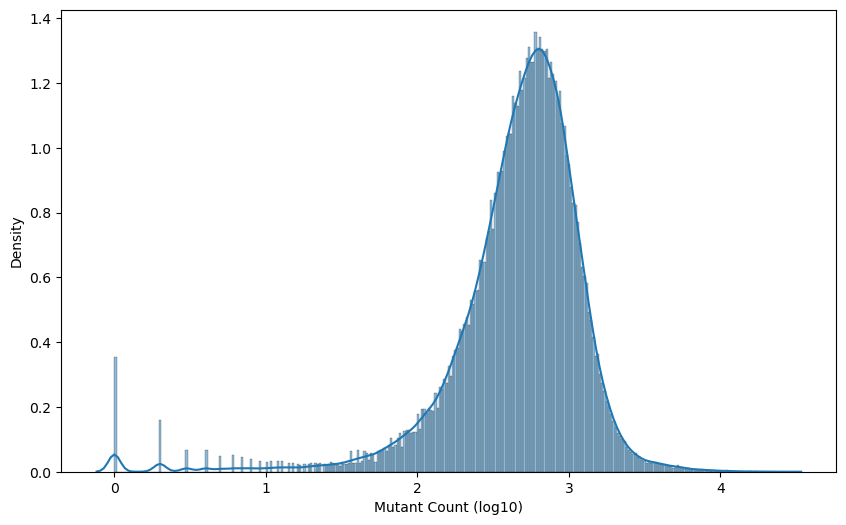

```python
# histogram of the mutant counts shows normal distrubution
fig,ax =plt.subplots(figsize=(10,6))

sns.histplot(np.log10(barcodes_found),
             stat="density",
             kde=True,
             kde_kws=dict(cut=3),
             ax=ax)

ax.set_xlabel('Mutant Count (log10)')
ax.set_ylabel('Density')

print ("Total Reads: %.3e" % barcode_count.sum())
print ("Average read number per barcode: %.3e"  % barcode_count.mean())
```

## Plasmid frequency vs. count frequency

```python
# sum the pacakged virus and plasmid count (CMV and Rep promoters replicates)
viable_summed_freq = viable_counts.groupby(level=['promoter', 'source'],axis=1).sum()
viable_summed_freq
```

| abs_pos | tile_num | aa | is_wt_aa | is_wt_codon | wt_bc | lib_type | enzyme | codon | aa-codon | promoter source barcode | CMV plasmid | CMV virus | Rep plasmid | Rep virus |
| --- | --- | --- | --- | --- | --- | --- | --- | --- | --- | --- | --- | --- | --- | --- |
| 1.0 | 0.0 | * | 0 | 0 | 0 | sub | bbsi | TAA | *-TAA | CACTGTCACACACTGACACT | 1690.0 | 1292.0 | 1979.0 | 1362.0 |
|  |  |  |  |  |  |  |  |  |  | CTGTGAGTGTGAGAGACACT | 1888.0 | 1223.0 | 1704.0 | 1887.0 |
|  |  |  |  |  |  |  |  | TAG | *-TAG | CTCTCACACAGTGAGTCTGA | 265.0 | 1058.0 | 314.0 | 164.0 |
|  |  |  |  |  |  |  |  |  |  | CAGAGACAGAGTCTGTCACT | 369.0 | 310.0 | 314.0 | 350.0 |
|  |  |  |  |  |  |  |  | TGA | *-TGA | ACACTGTCTCTGTCAGACAG | 3140.0 | 1923.0 | 2895.0 | 2149.0 |
| ... | ... | ... | ... | ... | ... | ... | ... | ... | ... | ... | ... | ... | ... | ... |
| 735.5 | 18.0 | W | 0 | 0 | 0 | ins | bbsi | TGG | W-TGG | AGTCTGAGAGACTCTGACTG | 12932.0 | 4804.0 | 16147.0 | 1089.0 |
|  |  | Y | 0 | 0 | 0 | ins | bbsi | TAC | Y-TAC | GACTCTCACTCACACTGTGA | 6049.0 | 626.0 | 6936.0 | 381.0 |
|  |  |  |  |  |  |  |  |  |  | TGTCTCAGTCACACTGTGTG | 2865.0 | 267.0 | 3517.0 | 354.0 |
|  |  |  |  |  |  |  |  | TAT | Y-TAT | CACTGTGTGAGTCTGAGAGT | 5919.0 | 486.0 | 5374.0 | 710.0 |
|  |  |  |  |  |  |  |  |  |  | TGTCAGACACTCTGAGTGTC | 5964.0 | 536.0 | 5346.0 | 697.0 |

207168 rows × 4 columns

```python
# combine the plasmid count and virus count, then take the log10 and drop the na
viable_summed_freq = viable_counts.groupby(level=['promoter', 'source'],axis=1).sum()
viable_summed_freq = viable_summed_freq.apply(lambda x: x/sum(x)).xs('CMV', level='promoter', axis=1)
viable_summed_freq = np.log10(viable_summed_freq).replace([np.inf, -np.inf], np.nan).dropna()
```

```python
viable_summed_freq
```

| abs_pos | tile_num | aa | is_wt_aa | is_wt_codon | wt_bc | lib_type | enzyme | codon | aa-codon | source barcode | plasmid | virus |
| --- | --- | --- | --- | --- | --- | --- | --- | --- | --- | --- | --- | --- |
| 1.0 | 0.0 | * | 0 | 0 | 0 | sub | bbsi | TAA | *-TAA | CACTGTCACACACTGACACT | -4.900451 | -5.178977 |
|  |  |  |  |  |  |  |  |  |  | CTGTGAGTGTGAGAGACACT | -4.852336 | -5.202813 |
|  |  |  |  |  |  |  |  | TAG | *-TAG | CTCTCACACAGTGAGTCTGA | -5.705092 | -5.265754 |
|  |  |  |  |  |  |  |  |  |  | CAGAGACAGAGTCTGTCACT | -5.561311 | -5.798878 |
|  |  |  |  |  |  |  |  | TGA | *-TGA | ACACTGTCTCTGTCAGACAG | -4.631408 | -5.006260 |
| ... | ... | ... | ... | ... | ... | ... | ... | ... | ... | ... | ... | ... |
| 735.5 | 18.0 | W | 0 | 0 | 0 | ins | bbsi | TGG | W-TGG | AGTCTGAGAGACTCTGACTG | -4.016672 | -4.608637 |
|  |  | Y | 0 | 0 | 0 | ins | bbsi | TAC | Y-TAC | GACTCTCACTCACACTGTGA | -4.346654 | -5.493665 |
|  |  |  |  |  |  |  |  |  |  | TGTCTCAGTCACACTGTGTG | -4.671213 | -5.863728 |
|  |  |  |  |  |  |  |  | TAT | Y-TAT | CACTGTGTGAGTCTGAGAGT | -4.356089 | -5.603603 |
|  |  |  |  |  |  |  |  |  |  | TGTCAGACACTCTGAGTGTC | -4.352800 | -5.561075 |

202653 rows × 2 columns

```python
# create a new column from difference between plasmid and virus log count
viable_summed_freq['selection'] = viable_summed_freq['virus'] - viable_summed_freq['plasmid']
viable_summed_freq
```

| abs_pos | tile_num | aa | is_wt_aa | is_wt_codon | wt_bc | lib_type | enzyme | codon | aa-codon | source barcode | plasmid | virus | selection |
| --- | --- | --- | --- | --- | --- | --- | --- | --- | --- | --- | --- | --- | --- |
| 1.0 | 0.0 | * | 0 | 0 | 0 | sub | bbsi | TAA | *-TAA | CACTGTCACACACTGACACT | -4.900451 | -5.178977 | -0.278526 |
|  |  |  |  |  |  |  |  |  |  | CTGTGAGTGTGAGAGACACT | -4.852336 | -5.202813 | -0.350478 |
|  |  |  |  |  |  |  |  | TAG | *-TAG | CTCTCACACAGTGAGTCTGA | -5.705092 | -5.265754 | 0.439338 |
|  |  |  |  |  |  |  |  |  |  | CAGAGACAGAGTCTGTCACT | -5.561311 | -5.798878 | -0.237567 |
|  |  |  |  |  |  |  |  | TGA | *-TGA | ACACTGTCTCTGTCAGACAG | -4.631408 | -5.006260 | -0.374853 |
| ... | ... | ... | ... | ... | ... | ... | ... | ... | ... | ... | ... | ... | ... |
| 735.5 | 18.0 | W | 0 | 0 | 0 | ins | bbsi | TGG | W-TGG | AGTCTGAGAGACTCTGACTG | -4.016672 | -4.608637 | -0.591965 |
|  |  | Y | 0 | 0 | 0 | ins | bbsi | TAC | Y-TAC | GACTCTCACTCACACTGTGA | -4.346654 | -5.493665 | -1.147011 |
|  |  |  |  |  |  |  |  |  |  | TGTCTCAGTCACACTGTGTG | -4.671213 | -5.863728 | -1.192516 |
|  |  |  |  |  |  |  |  | TAT | Y-TAT | CACTGTGTGAGTCTGAGAGT | -4.356089 | -5.603603 | -1.247514 |
|  |  |  |  |  |  |  |  |  |  | TGTCAGACACTCTGAGTGTC | -4.352800 | -5.561075 | -1.208275 |

202653 rows × 3 columns

```python
# create a new column to calculate the difference between wild type count and the mutant count.
viable_summed_freq['selection_wt_norm'] = viable_summed_freq['selection']- viable_summed_freq['selection'].xs(1,level='wt_bc').mean()
viable_summed_freq
```

| abs_pos | tile_num | aa | is_wt_aa | is_wt_codon | wt_bc | lib_type | enzyme | codon | aa-codon | source barcode | plasmid | virus | selection | selection_wt_norm |
| --- | --- | --- | --- | --- | --- | --- | --- | --- | --- | --- | --- | --- | --- | --- |
| 1.0 | 0.0 | * | 0 | 0 | 0 | sub | bbsi | TAA | *-TAA | CACTGTCACACACTGACACT | -4.900451 | -5.178977 | -0.278526 | -0.729077 |
|  |  |  |  |  |  |  |  |  |  | CTGTGAGTGTGAGAGACACT | -4.852336 | -5.202813 | -0.350478 | -0.801028 |
|  |  |  |  |  |  |  |  | TAG | *-TAG | CTCTCACACAGTGAGTCTGA | -5.705092 | -5.265754 | 0.439338 | -0.011213 |
|  |  |  |  |  |  |  |  |  |  | CAGAGACAGAGTCTGTCACT | -5.561311 | -5.798878 | -0.237567 | -0.688117 |
|  |  |  |  |  |  |  |  | TGA | *-TGA | ACACTGTCTCTGTCAGACAG | -4.631408 | -5.006260 | -0.374853 | -0.825403 |
| ... | ... | ... | ... | ... | ... | ... | ... | ... | ... | ... | ... | ... | ... | ... |
| 735.5 | 18.0 | W | 0 | 0 | 0 | ins | bbsi | TGG | W-TGG | AGTCTGAGAGACTCTGACTG | -4.016672 | -4.608637 | -0.591965 | -1.042515 |
|  |  | Y | 0 | 0 | 0 | ins | bbsi | TAC | Y-TAC | GACTCTCACTCACACTGTGA | -4.346654 | -5.493665 | -1.147011 | -1.597562 |
|  |  |  |  |  |  |  |  |  |  | TGTCTCAGTCACACTGTGTG | -4.671213 | -5.863728 | -1.192516 | -1.643066 |
|  |  |  |  |  |  |  |  | TAT | Y-TAT | CACTGTGTGAGTCTGAGAGT | -4.356089 | -5.603603 | -1.247514 | -1.698065 |
|  |  |  |  |  |  |  |  |  |  | TGTCAGACACTCTGAGTGTC | -4.352800 | -5.561075 | -1.208275 | -1.658825 |

202653 rows × 4 columns

```python
# sample the dataframe
viable_summed_freq_sample = viable_summed_freq.sample(10000, random_state=0)
viable_summed_freq_sample.head()
```

| abs_pos | tile_num | aa | is_wt_aa | is_wt_codon | wt_bc | lib_type | enzyme | codon | aa-codon | source barcode | plasmid | virus | selection | selection_wt_norm |
| --- | --- | --- | --- | --- | --- | --- | --- | --- | --- | --- | --- | --- | --- | --- |
| 352.5 | 9.0 | T | 0 | 0 | 0 | ins | bsmbi | ACC | T-ACC | TCTGACACACTCACAGTCAC | -5.385612 | -6.618142 | -1.232529 | -1.683080 |
| 344.5 | 8.0 | M | 0 | 0 | 0 | ins | bbsi | ATG | M-ATG | TGTCACTGAGTGTCTCTCTC | -5.455317 | -6.843082 | -1.387765 | -1.838316 |
| 357.5 | 9.0 | C | 0 | 0 | 0 | ins | bsmbi | TGC | C-TGC | CTCTGTGAGACAGACTCAGT | -5.547413 | -6.699175 | -1.151763 | -1.602313 |
| 178.0 | 4.0 | R | 0 | 0 | 0 | sub | bbsi | CGG | R-CGG | CACAGTGACTGTGAGAGACT | -5.455317 | -5.110688 | 0.344629 | -0.105922 |
| 470.0 | 12.0 | P | 0 | 0 | 0 | sub | bbsi | CCT | P-CCT | CACAGTGTGAGTCAGAGTGA | -6.343008 | -7.445142 | -1.102134 | -1.552684 |

```python
#create a wildtype data frame
viable_summed_freq_wt_barcodes = viable_summed_freq_sample.xs(1, level='wt_bc')
viable_summed_freq_wt_barcodes.head()
```

| abs_pos | tile_num | aa | is_wt_aa | is_wt_codon | lib_type | enzyme | codon | aa-codon | source barcode | plasmid | virus | selection | selection_wt_norm |
| --- | --- | --- | --- | --- | --- | --- | --- | --- | --- | --- | --- | --- | --- |
| 696.0 | 18.0 | P | 1 | 1 | sub | bbsi | CCC | P-CCC | TGAGTCTGTCAGTCTGTCAC | -5.070291 | -4.611448 | 0.458843 | 0.008293 |
| 345.0 | 9.0 | D | 1 | 1 | sub | bbsi | GAC | D-GAC | CTCACTGTGTCTCTCTGACA | -5.034216 | -4.657985 | 0.376231 | -0.074319 |
| 462.0 | 12.0 | F | 1 | 1 | sub | bbsi | TTT | F-TTT | CAGAGACTCAGAGACTCAGA | -5.789881 | -5.364928 | 0.424953 | -0.025597 |
| 657.0 | 17.0 | P | 1 | 1 | sub | bbsi | CCT | P-CCT | TCTCTCTGTCACTCTCTCTG | -4.798736 | -4.414195 | 0.384541 | -0.066009 |
|  |  |  |  |  |  |  |  |  | AGTGTGACAGACTCTGACTG | -5.281382 | -4.803101 | 0.478281 | 0.027730 |

```
(-8.0, -3.0)
```

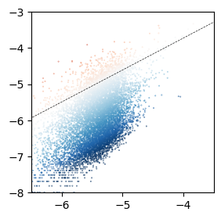

```python
# plot the sample dataframe to visualize the mutants assembily rate compare to the wildtype, which demostrate most of the mutants has lower package rate compare to wildtype
# But some mutants still illustrate better packaging compare to wildtype
fig,ax =plt.subplots(figsize=(3,3))

x = viable_summed_freq_sample['plasmid']
y = viable_summed_freq_sample['virus']
z = viable_summed_freq_sample['selection_wt_norm']

xx = viable_summed_freq_wt_barcodes['plasmid']
yy = viable_summed_freq_wt_barcodes['virus']

plt.scatter(x, y, c=z, cmap='RdBu_r', s= .1,alpha=.9,vmin=-2, vmax=2)

slope, intercept, r_value, viable_value, std_err = stats.linregress(xx, yy)
line_x = np.arange(-8.5,-2.5)
line_y = slope*line_x + intercept
plt.plot(line_x, line_y, c='black', linestyle='dashed', alpha=.9, lw=.5)
plt.xlim(-6.5, -3.5)
plt.ylim(-8, -3)
```

## Wildtype Vs VP1/2/3 stop codons

```python
#use the filtered dataframe
packaging_drop_bad_reps
```

| abs_pos | tile_num | aa | is_wt_aa | is_wt_codon | wt_bc | lib_type | enzyme | codon | aa-codon | promoter source virus_rep tech_rep measurement gen_id barcode | CMV plasmid 0 p-a count GEN00105092 | CMV plasmid 0 p-b count GEN00113847 | CMV plasmid 0 p-c count GEN00113848 | CMV virus 1 a count GEN00105099 | CMV virus 1 b count GEN00105101 | CMV virus 2 a count GEN00105100 | CMV virus 2 b count GEN00105102 | Rep plasmid 0 p-a count GEN00105091 | Rep plasmid 0 p-b count GEN00113849 | Rep plasmid 0 p-c count GEN00113850 | Rep plasmid 14 p-a count GEN00105087 | Rep plasmid 15 p-a count GEN00105088 | Rep virus 14 d count GEN00105089 | Rep virus 15 e count GEN00105090 | Rep virus 3 c count GEN00105097 | Rep virus 4 c count GEN00105098 |
| --- | --- | --- | --- | --- | --- | --- | --- | --- | --- | --- | --- | --- | --- | --- | --- | --- | --- | --- | --- | --- | --- | --- | --- | --- | --- | --- |
| 1.0 | 0.0 | * | 0 | 0 | 0 | sub | bbsi | TAA | *-TAA | CACTGTCACACACTGACACT | 574.0 | 556.0 | 560.0 | 253.0 | 258.0 | 106.0 | 167.0 | 606.0 | 641.0 | 680.0 | 52.0 | NaN | 40.0 | NaN | 415.0 | 206.0 |
|  |  |  |  |  |  |  |  |  |  | CTGTGAGTGTGAGAGACACT | 685.0 | 600.0 | 603.0 | 355.0 | 267.0 | 111.0 | 141.0 | 567.0 | 562.0 | 575.0 | NaN | NaN | NaN | NaN | 709.0 | 179.0 |
|  |  |  |  |  |  |  |  | TAG | *-TAG | CTCTCACACAGTGAGTCTGA | 112.0 | 59.0 | 94.0 | 36.0 | 20.0 | 7.0 | 9.0 | 106.0 | 74.0 | 134.0 | NaN | NaN | NaN | NaN | 32.0 | 13.0 |
|  |  |  |  |  |  |  |  |  |  | CAGAGACAGAGTCTGTCACT | 128.0 | 145.0 | 96.0 | 85.0 | 43.0 | 24.0 | 16.0 | 108.0 | 111.0 | 95.0 | NaN | NaN | NaN | NaN | 118.0 | 33.0 |
|  |  |  |  |  |  |  |  | TGA | *-TGA | ACACTGTCTCTGTCAGACAG | 1077.0 | 1127.0 | 936.0 | 397.0 | 331.0 | 137.0 | 241.0 | 853.0 | 920.0 | 1122.0 | NaN | NaN | NaN | NaN | 876.0 | 275.0 |
| ... | ... | ... | ... | ... | ... | ... | ... | ... | ... | ... | ... | ... | ... | ... | ... | ... | ... | ... | ... | ... | ... | ... | ... | ... | ... | ... |
| 735.5 | 18.0 | W | 0 | 0 | 0 | ins | bbsi | TGG | W-TGG | AGTCTGAGAGACTCTGACTG | 4825.0 | 4377.0 | 3730.0 | 280.0 | 223.0 | 11.0 | 40.0 | 5519.0 | 5229.0 | 5398.0 | NaN | 1.0 | NaN | 3.0 | 72.0 | 10.0 |
|  |  | Y | 0 | 0 | 0 | ins | bbsi | TAC | Y-TAC | GACTCTCACTCACACTGTGA | 1723.0 | 2314.0 | 2012.0 | 169.0 | 144.0 | 45.0 | 76.0 | 1991.0 | 2379.0 | 2566.0 | NaN | NaN | NaN | NaN | 36.0 | 7.0 |
|  |  |  |  |  |  |  |  |  |  | TGTCTCAGTCACACTGTGTG | 1001.0 | 989.0 | 875.0 | 60.0 | 47.0 | 4.0 | 5.0 | 1193.0 | 1082.0 | 1242.0 | NaN | NaN | NaN | NaN | 28.0 | 1.0 |
|  |  |  |  |  |  |  |  | TAT | Y-TAT | CACTGTGTGAGTCTGAGAGT | 2460.0 | 1885.0 | 1574.0 | 166.0 | 124.0 | 32.0 | 34.0 | 2177.0 | 1629.0 | 1568.0 | NaN | NaN | NaN | NaN | 76.0 | 14.0 |
|  |  |  |  |  |  |  |  |  |  | TGTCAGACACTCTGAGTGTC | 2179.0 | 2010.0 | 1775.0 | 169.0 | 167.0 | 22.0 | 54.0 | 1843.0 | 1795.0 | 1708.0 | NaN | NaN | NaN | 1.0 | 240.0 | 45.0 |

207168 rows × 16 columns

```python
packaging_drop_bad_reps.columns.get_level_values(level=0)
```

```
Index(['CMV', 'CMV', 'CMV', 'CMV', 'CMV', 'CMV', 'CMV', 'Rep', 'Rep', 'Rep',
       'Rep', 'Rep', 'Rep', 'Rep', 'Rep', 'Rep'],
      dtype='object', name='promoter')
```

```python
# select only the CMV promoter data
viable_selection = packaging_drop_bad_reps.loc[:, pd.IndexSlice['CMV']]
viable_selection
```

| abs_pos | tile_num | aa | is_wt_aa | is_wt_codon | wt_bc | lib_type | enzyme | codon | aa-codon | source virus_rep tech_rep measurement gen_id barcode | plasmid 0 p-a count GEN00105092 | plasmid 0 p-b count GEN00113847 | plasmid 0 p-c count GEN00113848 | virus 1 a count GEN00105099 | virus 1 b count GEN00105101 | virus 2 a count GEN00105100 | virus 2 b count GEN00105102 |
| --- | --- | --- | --- | --- | --- | --- | --- | --- | --- | --- | --- | --- | --- | --- | --- | --- | --- |
| 1.0 | 0.0 | * | 0 | 0 | 0 | sub | bbsi | TAA | *-TAA | CACTGTCACACACTGACACT | 574.0 | 556.0 | 560.0 | 253.0 | 258.0 | 106.0 | 167.0 |
|  |  |  |  |  |  |  |  |  |  | CTGTGAGTGTGAGAGACACT | 685.0 | 600.0 | 603.0 | 355.0 | 267.0 | 111.0 | 141.0 |
|  |  |  |  |  |  |  |  | TAG | *-TAG | CTCTCACACAGTGAGTCTGA | 112.0 | 59.0 | 94.0 | 36.0 | 20.0 | 7.0 | 9.0 |
|  |  |  |  |  |  |  |  |  |  | CAGAGACAGAGTCTGTCACT | 128.0 | 145.0 | 96.0 | 85.0 | 43.0 | 24.0 | 16.0 |
|  |  |  |  |  |  |  |  | TGA | *-TGA | ACACTGTCTCTGTCAGACAG | 1077.0 | 1127.0 | 936.0 | 397.0 | 331.0 | 137.0 | 241.0 |
| ... | ... | ... | ... | ... | ... | ... | ... | ... | ... | ... | ... | ... | ... | ... | ... | ... | ... |
| 735.5 | 18.0 | W | 0 | 0 | 0 | ins | bbsi | TGG | W-TGG | AGTCTGAGAGACTCTGACTG | 4825.0 | 4377.0 | 3730.0 | 280.0 | 223.0 | 11.0 | 40.0 |
|  |  | Y | 0 | 0 | 0 | ins | bbsi | TAC | Y-TAC | GACTCTCACTCACACTGTGA | 1723.0 | 2314.0 | 2012.0 | 169.0 | 144.0 | 45.0 | 76.0 |
|  |  |  |  |  |  |  |  |  |  | TGTCTCAGTCACACTGTGTG | 1001.0 | 989.0 | 875.0 | 60.0 | 47.0 | 4.0 | 5.0 |
|  |  |  |  |  |  |  |  | TAT | Y-TAT | CACTGTGTGAGTCTGAGAGT | 2460.0 | 1885.0 | 1574.0 | 166.0 | 124.0 | 32.0 | 34.0 |
|  |  |  |  |  |  |  |  |  |  | TGTCAGACACTCTGAGTGTC | 2179.0 | 2010.0 | 1775.0 | 169.0 | 167.0 | 22.0 | 54.0 |

207168 rows × 7 columns

```python
#sum the CMV plasmid replicate count and CMV virus replicate count.
viable_selection = viable_selection.groupby(['source'], axis=1).sum().apply(np.log2)
viable_selection
```

| abs_pos | tile_num | aa | is_wt_aa | is_wt_codon | wt_bc | lib_type | enzyme | codon | aa-codon | source barcode | plasmid | virus |
| --- | --- | --- | --- | --- | --- | --- | --- | --- | --- | --- | --- | --- |
| 1.0 | 0.0 | * | 0 | 0 | 0 | sub | bbsi | TAA | *-TAA | CACTGTCACACACTGACACT | 10.722808 | 9.614710 |
|  |  |  |  |  |  |  |  |  |  | CTGTGAGTGTGAGAGACACT | 10.882643 | 9.771489 |
|  |  |  |  |  |  |  |  | TAG | *-TAG | CTCTCACACAGTGAGTCTGA | 8.049849 | 6.169925 |
|  |  |  |  |  |  |  |  |  |  | CAGAGACAGAGTCTGTCACT | 8.527477 | 7.392317 |
|  |  |  |  |  |  |  |  | TGA | *-TGA | ACACTGTCTCTGTCAGACAG | 11.616549 | 10.111136 |
| ... | ... | ... | ... | ... | ... | ... | ... | ... | ... | ... | ... | ... |
| 735.5 | 18.0 | W | 0 | 0 | 0 | ins | bbsi | TGG | W-TGG | AGTCTGAGAGACTCTGACTG | 13.658658 | 9.113742 |
|  |  | Y | 0 | 0 | 0 | ins | bbsi | TAC | Y-TAC | GACTCTCACTCACACTGTGA | 12.562481 | 8.761551 |
|  |  |  |  |  |  |  |  |  |  | TGTCTCAGTCACACTGTGTG | 11.484319 | 6.857981 |
|  |  |  |  |  |  |  |  | TAT | Y-TAT | CACTGTGTGAGTCTGAGAGT | 12.531138 | 8.475733 |
|  |  |  |  |  |  |  |  |  |  | TGTCAGACACTCTGAGTGTC | 12.542065 | 8.686501 |

207168 rows × 2 columns

```python
# create a frequency column based on the virus/plasmid counts, drop the original columns
viable_selection['freq'] = viable_selection.apply(lambda x: x['virus']/x['plasmid'], axis=1)
viable_selection = viable_selection.drop(columns=['plasmid', 'virus'])
viable_selection
```

| abs_pos | tile_num | aa | is_wt_aa | is_wt_codon | wt_bc | lib_type | enzyme | codon | aa-codon | source barcode | freq |
| --- | --- | --- | --- | --- | --- | --- | --- | --- | --- | --- | --- |
| 1.0 | 0.0 | * | 0 | 0 | 0 | sub | bbsi | TAA | *-TAA | CACTGTCACACACTGACACT | 0.896660 |
|  |  |  |  |  |  |  |  |  |  | CTGTGAGTGTGAGAGACACT | 0.897897 |
|  |  |  |  |  |  |  |  | TAG | *-TAG | CTCTCACACAGTGAGTCTGA | 0.766465 |
|  |  |  |  |  |  |  |  |  |  | CAGAGACAGAGTCTGTCACT | 0.866882 |
|  |  |  |  |  |  |  |  | TGA | *-TGA | ACACTGTCTCTGTCAGACAG | 0.870408 |
| ... | ... | ... | ... | ... | ... | ... | ... | ... | ... | ... | ... |
| 735.5 | 18.0 | W | 0 | 0 | 0 | ins | bbsi | TGG | W-TGG | AGTCTGAGAGACTCTGACTG | 0.667250 |
|  |  | Y | 0 | 0 | 0 | ins | bbsi | TAC | Y-TAC | GACTCTCACTCACACTGTGA | 0.697438 |
|  |  |  |  |  |  |  |  |  |  | TGTCTCAGTCACACTGTGTG | 0.597160 |
|  |  |  |  |  |  |  |  | TAT | Y-TAT | CACTGTGTGAGTCTGAGAGT | 0.676374 |
|  |  |  |  |  |  |  |  |  |  | TGTCAGACACTCTGAGTGTC | 0.692589 |

207168 rows × 1 columns

```python
# create a wildtype subdataframe and stop codon mutants before position 204, and stop codon mutants after postion 204
WT = viable_selection.query("wt_bc==1").dropna().values
VP12_stops = viable_selection.query("(abs_pos < 204) & (aa == '*')").dropna().values
VP3_stops = viable_selection.query("(abs_pos > 204) & (aa == '*')").dropna().values
```

```python
# exam the datarame of the wildtype
viable_selection.query("wt_bc==1").dropna()
```

| abs_pos | tile_num | aa | is_wt_aa | is_wt_codon | wt_bc | lib_type | enzyme | codon | aa-codon | source barcode | freq |
| --- | --- | --- | --- | --- | --- | --- | --- | --- | --- | --- | --- |
| 1.0 | 0.0 | M | 1 | 1 | 1 | sub | bbsi | ATG | M-ATG | TGACAGAGAGACACTCAGAC | 1.179444 |
|  |  |  |  |  |  |  |  |  |  | AGTCTGAGAGAGAGAGACAC | 1.279968 |
|  |  |  |  |  |  |  |  |  |  | CTGTGTGACAGTCAGAGACT | 1.125711 |
|  |  |  |  |  |  |  |  |  |  | TGTCTGTCAGACACTCAGAC | 1.076208 |
|  |  |  |  |  |  |  |  |  |  | GTGACTGTGAGTCTGTCTCT | 1.189663 |
| ... | ... | ... | ... | ... | ... | ... | ... | ... | ... | ... | ... |
| 696.0 | 18.0 | P | 1 | 1 | 1 | sub | bbsi | CCC | P-CCC | ACAGTCAGTCTGTGTGTCAG | 1.048696 |
|  |  |  |  |  |  |  |  |  |  | CAGTCACACTCACACTGTGT | 1.060801 |
|  |  |  |  |  |  |  |  |  |  | TCTGTCTCTGTGTCAGAGTG | 0.993663 |
|  |  |  |  |  |  |  |  |  |  | GAGTGTCTCTGAGTGACAGT | 1.026724 |
|  |  |  |  |  |  |  |  |  |  | TGAGTCTGTCAGTCTGTCAC | 1.093380 |

401 rows × 1 columns

```python
# exam the dataframe of VP1/2 stop
viable_selection.query("(abs_pos < 204) & (aa == '*')").dropna()
```

| abs_pos | tile_num | aa | is_wt_aa | is_wt_codon | wt_bc | lib_type | enzyme | codon | aa-codon | source barcode | freq |
| --- | --- | --- | --- | --- | --- | --- | --- | --- | --- | --- | --- |
| 1.0 | 0.0 | * | 0 | 0 | 0 | sub | bbsi | TAA | *-TAA | CACTGTCACACACTGACACT | 0.896660 |
|  |  |  |  |  |  |  |  |  |  | CTGTGAGTGTGAGAGACACT | 0.897897 |
|  |  |  |  |  |  |  |  | TAG | *-TAG | CTCTCACACAGTGAGTCTGA | 0.766465 |
|  |  |  |  |  |  |  |  |  |  | CAGAGACAGAGTCTGTCACT | 0.866882 |
|  |  |  |  |  |  |  |  | TGA | *-TGA | ACACTGTCTCTGTCAGACAG | 0.870408 |
| ... | ... | ... | ... | ... | ... | ... | ... | ... | ... | ... | ... |
| 203.0 | 5.0 | * | 0 | 0 | 0 | sub | bbsi | TAA | *-TAA | ACACAGTCTGTCACACTGAG | 0.722379 |
|  |  |  |  |  |  |  |  | TAG | *-TAG | AGACTGAGTCACTGAGTCAG | 0.856743 |
|  |  |  |  |  |  |  |  |  |  | GTGACAGACACAGACACTCA | 0.779690 |
|  |  |  |  |  |  |  |  | TGA | *-TGA | ACTGTGACTCAGTGACACAC | 0.823271 |
|  |  |  |  |  |  |  |  |  |  | TGACTCAGACTGACTCTCTG | 0.723401 |

1236 rows × 1 columns

```python
# exam the dataframe of VP3 stop
viable_selection.query("(abs_pos > 204) & (aa == '*')").dropna()
```

| abs_pos | tile_num | aa | is_wt_aa | is_wt_codon | wt_bc | lib_type | enzyme | codon | aa-codon | source barcode | freq |
| --- | --- | --- | --- | --- | --- | --- | --- | --- | --- | --- | --- |
| 205.0 | 5.0 | * | 0 | 0 | 0 | sub | bbsi | TAA | *-TAA | CTGTCACTGAGACTCTCTCA | 0.747534 |
|  |  |  |  |  |  |  |  |  |  | TCACAGTCACAGACTCTGTC | 0.847721 |
|  |  |  |  |  |  |  |  | TAG | *-TAG | TGACTGAGAGTCTCTGACAC | 0.877980 |
|  |  |  |  |  |  |  |  |  |  | TCACACACAGAGTCTCTCTG | 0.798751 |
|  |  |  |  |  |  |  |  | TGA | *-TGA | TGAGACACTCAGTGAGAGTC | 0.719342 |
| ... | ... | ... | ... | ... | ... | ... | ... | ... | ... | ... | ... |
| 735.0 | 18.0 | * | 0 | 0 | 0 | sub | bbsi | TAA | *-TAA | CAGTGAGTCAGACACTCAGA | 0.561112 |
|  |  |  |  |  |  |  |  |  |  | AGACACTGACACTGTCACTG | 0.686996 |
|  |  |  |  |  |  |  |  | TAG | *-TAG | GAGAGAGAGACAGAGAGAGT | 0.551570 |
|  |  |  |  |  |  |  |  |  |  | AGAGAGTCACACAGTGAGTG | 0.550223 |
|  |  |  |  |  |  |  |  | TGA | *-TGA | TCACTGTCACAGAGACTCAC | 0.716834 |

3471 rows × 1 columns

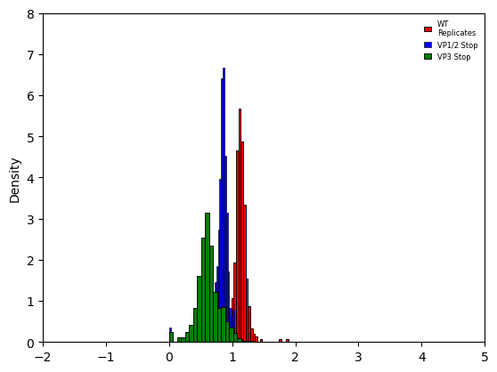

```python
#plot the fequency histogram based on wildtype, VP1/2 stop, VP3 stop to illustrate how the early stop codon in different region affect the packaging rate.
g = sns.histplot(WT, bins=50, stat='density', facecolor='red', label='WT\nReplicates')
sns.histplot(VP12_stops, bins=50, stat='density', facecolor='blue', label='VP1/2 Stop')
sns.histplot(VP3_stops, bins=50, stat='density', facecolor="green", label='VP3 Stop')
g.set_xlabel("")
g.set_ylabel("Density")
g.set_xlim((-2,5))
g.set_ylim((0,8))

plt.legend(frameon=False,columnspacing=.1,handlelength=1,fontsize=6)
plt.show()
```

```python
# create three groups of value based on substituion, insertion and deletion.
sub = viable_selection.query("(aa != '*') & (lib_type == 'sub')").dropna().values
ins = viable_selection.query("(aa != '*') & (lib_type == 'ins')").dropna().values
deletion = viable_selection.query("(aa != '*') & (lib_type == 'del')").dropna().values
```

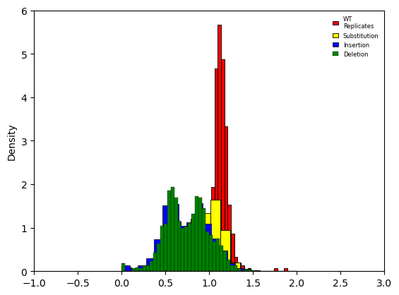

```python
# plot a histogram based on the mutation type.
g = sns.histplot(WT, bins=50, stat='density', facecolor='red', label='WT\nReplicates')
sns.histplot(sub, bins=50, stat='density', facecolor='yellow', label='Substitution')
sns.histplot(ins, bins=50, stat='density', facecolor='blue', label='Insertion')
sns.histplot(deletion, bins=50, stat='density', facecolor="green", label='Deletion')
g.set_xlabel("")
g.set_ylabel("Density")
g.set_xlim((-1,3))
g.set_ylim((0,6))

plt.legend(frameon=False,columnspacing=.1,handlelength=1,fontsize=6)
plt.show()
```

# Mouse organ distribution data

```python
# create a dataframe object for the mouse experimental data processed from the fastq data
mouse_all = pd.read_csv("data/aav_mouse_all.csv.gz", index_col=list(range(0,11)), header=list(range(0,6)))
```

```python
#make a copy of the dataframe
organ_dis = mouse_all.copy()
```

```python
organ_dis
```

| abs_pos | tile_num | aa | is_wt_aa | is_wt_codon | wt_bc | lib_type | enzyme | codon | aa-codon | organ virus mouse replicate prep lib_num barcode | blood 1 qiagen 97 | blood 1 2 qiagen 98 | blood 1 3 qiagen 99 | blood 1 4 qiagen 100 | blood 2 1 qiagen 101 | blood 2 1 qiagen 102 | blood 2 3 1 qiagen 103 | blood 2 4 1 qiagen 104 | liver 1 qiagen 9 | liver 1 2 qiagen 10 | ... | lung 1 2 3 mini 26 | lung 2 1 0 GP 31 | lung 2 1 mini 28 | lung 2 1 mini 29 | lung 2 1 3 mini 30 | lung 2 0 GP 36 | lung 2 1 mini 32 | lung 2 mini 33 | … |
| --- | --- | --- | --- | --- | --- | --- | --- | --- | --- | --- | --- | --- | --- | --- | --- | --- | --- | --- | --- | --- | --- | --- | --- | --- | --- | --- | --- | --- | --- | --- |
| 1.0 | 0.0 | * | 0 | 0 | 0 | sub | bbsi | TAA | *-TAA | CACTGTCACACACTGACACT | 70.0 | 70.0 | 57.0 | 148.0 | 275.0 | 96.0 | 174.0 | 177.0 | NaN | NaN | ... | 57.0 | NaN | 16.0 | 7.0 | 21.0 | 54.0 | NaN | 8.0 | … |
|  |  |  |  |  |  |  |  |  |  | CTGTGAGTGTGAGAGACACT | 101.0 | 64.0 | 62.0 | 188.0 | 317.0 | 150.0 | 148.0 | 192.0 | NaN | NaN | ... | 35.0 | NaN | 18.0 | NaN | NaN | NaN | NaN | NaN | … |
|  |  |  |  |  |  |  |  | TAG | *-TAG | CAGAGACAGAGTCTGTCACT | 11.0 | 19.0 | 8.0 | 49.0 | 54.0 | 37.0 | 42.0 | 49.0 | NaN | NaN | ... | NaN | NaN | NaN | 7.0 | NaN | NaN | NaN | NaN | … |
|  |  |  |  |  |  |  |  |  |  | CTCTCACACAGTGAGTCTGA | 10.0 | 12.0 | 8.0 | 8.0 | 37.0 | 12.0 | 22.0 | 36.0 | NaN | NaN | ... | NaN | NaN | NaN | 2.0 | NaN | 50.0 | NaN | 8.0 | … |
|  |  |  |  |  |  |  |  | TGA | *-TGA | ACACTGTCTCTGTCAGACAG | 114.0 | 112.0 | 89.0 | 175.0 | 467.0 | 202.0 | 149.0 | 253.0 | NaN | NaN | ... | NaN | NaN | 8.0 | 28.0 | 11.0 | NaN | 126.0 | NaN | … |
| ... | ... | ... | ... | ... | ... | ... | ... | ... | ... | ... | ... | ... | ... | ... | ... | ... | ... | ... | ... | ... | ... | ... | ... | ... | ... | ... | ... | ... | ... | … |
| 735.5 | 18.0 | W | 0 | 0 | 0 | ins | bbsi | TGG | W-TGG | GACTCTGTGTCTCAGACAGT | 20.0 | 7.0 | 9.0 | 21.0 | 2.0 | 12.0 | 5.0 | 57.0 | 1.0 | NaN | ... | 1.0 | NaN | 5.0 | 14.0 | 8.0 | NaN | 14.0 | 8.0 | … |
|  |  | Y | 0 | 0 | 0 | ins | bbsi | TAC | Y-TAC | GACTCTCACTCACACTGTGA | 23.0 | 15.0 | 9.0 | 48.0 | 9.0 | 34.0 | 17.0 | 19.0 | NaN | NaN | ... | NaN | 82.0 | NaN | 10.0 | NaN | 90.0 | 26.0 | 12.0 | … |
|  |  |  |  |  |  |  |  |  |  | TGTCTCAGTCACACTGTGTG | 9.0 | 18.0 | 1.0 | 9.0 | 12.0 | 2.0 | 11.0 | 9.0 | NaN | NaN | ... | 56.0 | NaN | 5.0 | NaN | NaN | 2.0 | NaN | NaN | … |
|  |  |  |  |  |  |  |  | TAT | Y-TAT | CACTGTGTGAGTCTGAGAGT | 15.0 | 13.0 | 10.0 | 16.0 | NaN | 26.0 | 20.0 | 24.0 | NaN | NaN | ... | NaN | 76.0 | 19.0 | 11.0 | NaN | 8.0 | NaN | 25.0 | … |
|  |  |  |  |  |  |  |  |  |  | TGTCAGACACTCTGAGTGTC | 3.0 | 6.0 | 3.0 | 11.0 | NaN | 17.0 | 17.0 | 52.0 | NaN | NaN | ... | NaN | 84.0 | NaN | 5.0 | NaN | NaN | NaN | NaN | … |

207168 rows × 75 columns

## Examine columns and indexes levels

```python
organ_dis.columns.get_level_values(level=0).unique()
```

```
Index(['blood', 'liver', 'spleen', 'heart', 'kidney', 'lung'], dtype='object', name='organ')
```

```python
organ_dis.columns.get_level_values(level=1).unique()
```

```
Index(['1', '2'], dtype='object', name='virus')
```

```python
organ_dis.columns.get_level_values(level=2).unique()
```

```
Index(['1', '2', '3', '4'], dtype='object', name='mouse')
```

```python
organ_dis.columns.get_level_values(level=3).unique().astype('int').sort_values()
```

```
Index([0, 1, 2, 3, 4], dtype='int64', name='replicate')
```

```python
organ_dis.columns.get_level_values(level=4).unique()
```

```
Index(['qiagen', 'GP', 'mini'], dtype='object', name='prep')
```

```python
organ_dis.columns.get_level_values(level=5).unique().astype('int').sort_values()
```

```
Index([  1,   2,   3,   4,   5,   6,   7,   8,   9,  10,  11,  12,  13,  14,
        15,  16,  17,  18,  19,  20,  21,  22,  23,  24,  25,  26,  27,  28,
        29,  30,  31,  32,  33,  34,  35,  36,  37,  38,  39,  40,  41,  42,
        43,  44,  45,  46,  47,  48,  49,  50,  51,  97,  98,  99, 100, 101,
       102, 103, 104],
      dtype='int64', name='lib_num')
```

```python
organ_dis.index.get_level_values(level=0).unique().astype('int').sort_values()
```

```
Index([  1,   1,   2,   2,   3,   3,   4,   4,   5,   5,
       ...
       731, 731, 732, 732, 733, 733, 734, 734, 735, 735],
      dtype='int64', name='abs_pos', length=1470)
```

```python
organ_dis.index.get_level_values(level=1).unique()
```

```
Index(['0.0', 'lookup_NA', '1.0', '2.0', '3.0', '4.0', '5.0', '6.0', '7.0',
       '8.0', '9.0', '10.0', '11.0', '12.0', '13.0', '14.0', '15.0', '16.0',
       '17.0', '18.0'],
      dtype='object', name='tile_num')
```

```python
organ_dis.index.get_level_values(level=2).unique()
```

```
Index(['*', '-', 'A', 'C', 'D', 'E', 'F', 'G', 'H', 'I', 'K', 'L', 'M', 'N',
       'P', 'Q', 'R', 'S', 'T', 'V', 'W', 'Y'],
      dtype='object', name='aa')
```

```python
organ_dis.index.get_level_values(level=3).unique()
```

```
Index([0, 1], dtype='int64', name='is_wt_aa')
```

```python
organ_dis.index.get_level_values(level=4).unique()
```

```
Index([0, 1], dtype='int64', name='is_wt_codon')
```

```python
organ_dis.index.get_level_values(level=5).unique()
```

```
Index([0, 1], dtype='int64', name='wt_bc')
```

```python
organ_dis.index.get_level_values(level=6).unique()
```

```
Index(['sub', 'del', 'ins'], dtype='object', name='lib_type')
```

```python
organ_dis.index.get_level_values(level=7).unique()
```

```
Index(['bbsi', 'lookup_NA', 'bsmbi'], dtype='object', name='enzyme')
```

```python
organ_dis.index.get_level_values(level=8).unique()
```

```
Index(['TAA', 'TAG', 'TGA', '---', 'GCA', 'GCC', 'GCG', 'GCT', 'TGC', 'TGT',
       'GAC', 'GAT', 'GAA', 'GAG', 'TTC', 'TTT', 'GGA', 'GGC', 'GGG', 'GGT',
       'CAC', 'CAT', 'ATA', 'ATC', 'ATT', 'AAA', 'AAG', 'CTA', 'CTG', 'CTT',
       'TTA', 'TTG', 'ATG', 'AAC', 'AAT', 'CCA', 'CCC', 'CCG', 'CCT', 'CAA',
       'CAG', 'AGA', 'AGG', 'CGA', 'CGC', 'CGG', 'CGT', 'AGC', 'AGT', 'TCA',
       'TCC', 'TCG', 'TCT', 'ACA', 'ACC', 'ACG', 'ACT', 'GTA', 'GTC', 'GTG',
       'GTT', 'TGG', 'TAC', 'TAT', 'CTC'],
      dtype='object', name='codon')
```

```python
organ_dis.index.get_level_values(level=9).unique()
```

```
Index(['*-TAA', '*-TAG', '*-TGA', '-----', 'A-GCA', 'A-GCC', 'A-GCG', 'A-GCT',
       'C-TGC', 'C-TGT', 'D-GAC', 'D-GAT', 'E-GAA', 'E-GAG', 'F-TTC', 'F-TTT',
       'G-GGA', 'G-GGC', 'G-GGG', 'G-GGT', 'H-CAC', 'H-CAT', 'I-ATA', 'I-ATC',
       'I-ATT', 'K-AAA', 'K-AAG', 'L-CTA', 'L-CTG', 'L-CTT', 'L-TTA', 'L-TTG',
       'M-ATG', 'N-AAC', 'N-AAT', 'P-CCA', 'P-CCC', 'P-CCG', 'P-CCT', 'Q-CAA',
       'Q-CAG', 'R-AGA', 'R-AGG', 'R-CGA', 'R-CGC', 'R-CGG', 'R-CGT', 'S-AGC',
       'S-AGT', 'S-TCA', 'S-TCC', 'S-TCG', 'S-TCT', 'T-ACA', 'T-ACC', 'T-ACG',
       'T-ACT', 'V-GTA', 'V-GTC', 'V-GTG', 'V-GTT', 'W-TGG', 'Y-TAC', 'Y-TAT',
       'L-CTC'],
      dtype='object', name='aa-codon')
```

```python
organ_dis.index.get_level_values(level=10).unique()
```

```
Index(['CACTGTCACACACTGACACT', 'CTGTGAGTGTGAGAGACACT', 'CAGAGACAGAGTCTGTCACT',
       'CTCTCACACAGTGAGTCTGA', 'ACACTGTCTCTGTCAGACAG', 'CACTCTGTGTGAGACAGTGT',
       'AGACAGTGAGTGTGTGTCTG', 'AGTCAGAGTCACACTCAGAG', 'CTCTCACACTGTGTCACACA',
       'TGTGTCACTCAGTGTGACTC',
       ...
       'CTCAGAGTCACTCAGAGACA', 'TGACTGAGTGTGTGTGACAC', 'AGTCTGAGAGACTCTGACTG',
       'AGTCTGTCTGACTGTCAGAG', 'GACAGTGTGTCAGACTCTCA', 'GACTCTGTGTCTCAGACAGT',
       'GACTCTCACTCACACTGTGA', 'TGTCTCAGTCACACTGTGTG', 'CACTGTGTGAGTCTGAGAGT',
       'TGTCAGACACTCTGAGTGTC'],
      dtype='object', name='barcode', length=206455)
```

## Filter out low count and outliers

```python
ogran_dist_filtered = organ_dis.where((organ_dis > 10) & (organ_dis < 31000), np.nan)
ogran_dist_filtered
```

| abs_pos | tile_num | aa | is_wt_aa | is_wt_codon | wt_bc | lib_type | enzyme | codon | aa-codon | organ virus mouse replicate prep lib_num barcode | blood 1 qiagen 97 | blood 1 2 qiagen 98 | blood 1 3 qiagen 99 | blood 1 4 qiagen 100 | blood 2 1 qiagen 101 | blood 2 1 qiagen 102 | blood 2 3 1 qiagen 103 | blood 2 4 1 qiagen 104 | liver 1 qiagen 9 | liver 1 2 qiagen 10 | ... | lung 1 2 3 mini 26 | lung 2 1 0 GP 31 | lung 2 1 mini 28 | lung 2 1 mini 29 | lung 2 1 3 mini 30 | lung 2 0 GP 36 | lung 2 1 mini 32 | lung 2 mini 33 | … |
| --- | --- | --- | --- | --- | --- | --- | --- | --- | --- | --- | --- | --- | --- | --- | --- | --- | --- | --- | --- | --- | --- | --- | --- | --- | --- | --- | --- | --- | --- | --- |
| 1.0 | 0.0 | * | 0 | 0 | 0 | sub | bbsi | TAA | *-TAA | CACTGTCACACACTGACACT | 70.0 | 70.0 | 57.0 | 148.0 | 275.0 | 96.0 | 174.0 | 177.0 | NaN | NaN | ... | 57.0 | NaN | 16.0 | NaN | 21.0 | 54.0 | NaN | NaN | … |
|  |  |  |  |  |  |  |  |  |  | CTGTGAGTGTGAGAGACACT | 101.0 | 64.0 | 62.0 | 188.0 | 317.0 | 150.0 | 148.0 | 192.0 | NaN | NaN | ... | 35.0 | NaN | 18.0 | NaN | NaN | NaN | NaN | NaN | … |
|  |  |  |  |  |  |  |  | TAG | *-TAG | CAGAGACAGAGTCTGTCACT | 11.0 | 19.0 | NaN | 49.0 | 54.0 | 37.0 | 42.0 | 49.0 | NaN | NaN | ... | NaN | NaN | NaN | NaN | NaN | NaN | NaN | NaN | … |
|  |  |  |  |  |  |  |  |  |  | CTCTCACACAGTGAGTCTGA | NaN | 12.0 | NaN | NaN | 37.0 | 12.0 | 22.0 | 36.0 | NaN | NaN | ... | NaN | NaN | NaN | NaN | NaN | 50.0 | NaN | NaN | … |
|  |  |  |  |  |  |  |  | TGA | *-TGA | ACACTGTCTCTGTCAGACAG | 114.0 | 112.0 | 89.0 | 175.0 | 467.0 | 202.0 | 149.0 | 253.0 | NaN | NaN | ... | NaN | NaN | NaN | 28.0 | 11.0 | NaN | 126.0 | NaN | … |
| ... | ... | ... | ... | ... | ... | ... | ... | ... | ... | ... | ... | ... | ... | ... | ... | ... | ... | ... | ... | ... | ... | ... | ... | ... | ... | ... | ... | ... | ... | … |
| 735.5 | 18.0 | W | 0 | 0 | 0 | ins | bbsi | TGG | W-TGG | GACTCTGTGTCTCAGACAGT | 20.0 | NaN | NaN | 21.0 | NaN | 12.0 | NaN | 57.0 | NaN | NaN | ... | NaN | NaN | NaN | 14.0 | NaN | NaN | 14.0 | NaN | … |
|  |  | Y | 0 | 0 | 0 | ins | bbsi | TAC | Y-TAC | GACTCTCACTCACACTGTGA | 23.0 | 15.0 | NaN | 48.0 | NaN | 34.0 | 17.0 | 19.0 | NaN | NaN | ... | NaN | 82.0 | NaN | NaN | NaN | 90.0 | 26.0 | 12.0 | … |
|  |  |  |  |  |  |  |  |  |  | TGTCTCAGTCACACTGTGTG | NaN | 18.0 | NaN | NaN | 12.0 | NaN | 11.0 | NaN | NaN | NaN | ... | 56.0 | NaN | NaN | NaN | NaN | NaN | NaN | NaN | … |
|  |  |  |  |  |  |  |  | TAT | Y-TAT | CACTGTGTGAGTCTGAGAGT | 15.0 | 13.0 | NaN | 16.0 | NaN | 26.0 | 20.0 | 24.0 | NaN | NaN | ... | NaN | 76.0 | 19.0 | 11.0 | NaN | NaN | NaN | 25.0 | … |
|  |  |  |  |  |  |  |  |  |  | TGTCAGACACTCTGAGTGTC | NaN | NaN | NaN | 11.0 | NaN | 17.0 | 17.0 | 52.0 | NaN | NaN | ... | NaN | 84.0 | NaN | NaN | NaN | NaN | NaN | NaN | … |

207168 rows × 75 columns

```python
# take the average of count for the same variant
viable_selection_filtered = viable_selection.groupby(['abs_pos', 'aa', 'wt_bc', 'lib_type']).mean()
# use the packaging dataframe to remove variant that not package efficently
viable_selection_filtered= viable_selection_filtered[viable_selection_filtered['freq']>1]
#reset the vairnat information index to column name
viable_selection_filtered = viable_selection_filtered.reset_index().set_index(['abs_pos', 'aa', 'wt_bc', 'lib_type'])
viable_selection_filtered
```

| abs_pos | aa | wt_bc | source lib_type | freq |
| --- | --- | --- | --- | --- |
| 1.0 | M | 1 | sub | 1.152306 |
| 2.0 | R | 0 | sub | 1.020779 |
| 2.5 | A | 0 | ins | 1.048862 |
| 3.0 | - | 0 | del | 1.032377 |
|  | A | 0 | sub | 1.000402 |
| ... | ... | ... | ... | ... |
| 734.0 | T | 0 | sub | 1.084539 |
|  | V | 0 | sub | 1.040033 |
| 735.0 | I | 0 | sub | 1.108801 |
|  | L | 0 | sub | 1.119326 |
|  | V | 0 | sub | 1.033308 |

6645 rows × 1 columns

```python
#degenerate the counts to unique variant
mouse_counts_aa_summed =  organ_dis.groupby(level=['abs_pos', 'aa','wt_bc', 'lib_type'], axis=0).sum()
mouse_counts_aa_summed
```

| abs_pos | aa | wt_bc | organ virus mouse replicate prep lib_num lib_type | blood 1 qiagen 97 | blood 1 2 qiagen 98 | blood 1 3 qiagen 99 | blood 1 4 qiagen 100 | blood 2 1 qiagen 101 | blood 2 1 qiagen 102 | blood 2 3 1 qiagen 103 | blood 2 4 1 qiagen 104 | liver 1 qiagen 9 | liver 1 2 qiagen 10 | ... | lung 1 2 3 mini 26 | lung 2 1 0 GP 31 | lung 2 1 mini 28 | lung 2 1 mini 29 | lung 2 1 3 mini 30 | lung 2 0 GP 36 | lung 2 1 mini 32 | lung 2 mini 33 | lung 2 3 mini 34 | lung 2 4 mini 35 |
| --- | --- | --- | --- | --- | --- | --- | --- | --- | --- | --- | --- | --- | --- | --- | --- | --- | --- | --- | --- | --- | --- | --- | --- | --- |
| 1.0 | * | 0 | sub | 324.0 | 328.0 | 244.0 | 630.0 | 1269.0 | 532.0 | 575.0 | 758.0 | 0.0 | 0.0 | ... | 92.0 | 0.0 | 42.0 | 49.0 | 32.0 | 105.0 | 126.0 | 16.0 | 206.0 | 2.0 |
|  | - | 0 | del | 0.0 | 0.0 | 0.0 | 0.0 | 1.0 | 0.0 | 0.0 | 0.0 | 0.0 | 0.0 | ... | 0.0 | 0.0 | 0.0 | 0.0 | 1.0 | 0.0 | 0.0 | 0.0 | 0.0 | 0.0 |
|  | A | 0 | sub | 103.0 | 77.0 | 46.0 | 136.0 | 101.0 | 101.0 | 108.0 | 241.0 | 0.0 | 0.0 | ... | 0.0 | 0.0 | 4.0 | 1.0 | 35.0 | 74.0 | 1.0 | 0.0 | 68.0 | 0.0 |
|  | C | 0 | sub | 172.0 | 224.0 | 157.0 | 399.0 | 632.0 | 495.0 | 461.0 | 845.0 | 0.0 | 0.0 | ... | 334.0 | 311.0 | 56.0 | 110.0 | 170.0 | 206.0 | 63.0 | 122.0 | 157.0 | 0.0 |
|  | D | 0 | sub | 19.0 | 18.0 | 25.0 | 25.0 | 77.0 | 44.0 | 20.0 | 70.0 | 0.0 | 0.0 | ... | 1.0 | 0.0 | 0.0 | 0.0 | 0.0 | 0.0 | 9.0 | 35.0 | 26.0 | 0.0 |
| ... | ... | ... | ... | ... | ... | ... | ... | ... | ... | ... | ... | ... | ... | ... | ... | ... | ... | ... | ... | ... | ... | ... | ... | ... |
| 735.5 | S | 0 | ins | 1789.0 | 1594.0 | 1265.0 | 3112.0 | 5108.0 | 3110.0 | 2759.0 | 3896.0 | 4176.0 | 2741.0 | ... | 3286.0 | 2877.0 | 977.0 | 1465.0 | 1610.0 | 3295.0 | 2068.0 | 1413.0 | 1754.0 | 12.0 |
|  | T | 0 | ins | 305.0 | 366.0 | 273.0 | 720.0 | 1034.0 | 883.0 | 658.0 | 1204.0 | 2.0 | 1.0 | ... | 724.0 | 688.0 | 210.0 | 276.0 | 507.0 | 724.0 | 717.0 | 332.0 | 498.0 | 0.0 |
|  | V | 0 | ins | 988.0 | 971.0 | 747.0 | 2109.0 | 3280.0 | 2646.0 | 1910.0 | 2861.0 | 3086.0 | 2286.0 | ... | 3440.0 | 3563.0 | 1341.0 | 1508.0 | 2041.0 | 3970.0 | 2840.0 | 1856.0 | 1860.0 | 11.0 |
|  | W | 0 | ins | 79.0 | 62.0 | 30.0 | 89.0 | 302.0 | 125.0 | 160.0 | 206.0 | 1.0 | 1146.0 | ... | 1.0 | 400.0 | 128.0 | 115.0 | 92.0 | 0.0 | 85.0 | 85.0 | 154.0 | 0.0 |
|  | Y | 0 | ins | 50.0 | 52.0 | 23.0 | 84.0 | 21.0 | 79.0 | 65.0 | 104.0 | 0.0 | 0.0 | ... | 56.0 | 242.0 | 24.0 | 26.0 | 0.0 | 100.0 | 26.0 | 37.0 | 21.0 | 0.0 |

30889 rows × 75 columns

```python
# replace the counts to frequency
mouse_counts_aa_freq = mouse_counts_aa_summed.apply(lambda x: x/np.nansum(x))
#reset the index based on the variant information
mouse_counts_aa_freq = mouse_counts_aa_freq.reset_index().set_index(['abs_pos', 'aa', 'wt_bc', 'lib_type'])
mouse_counts_aa_freq
```

| abs_pos | aa | wt_bc | organ virus mouse replicate prep lib_num lib_type | blood 1 qiagen 97 | blood 1 2 qiagen 98 | blood 1 3 qiagen 99 | blood 1 4 qiagen 100 | blood 2 1 qiagen 101 | blood 2 1 qiagen 102 | blood 2 3 1 qiagen 103 | blood 2 4 1 qiagen 104 | liver 1 qiagen 9 | liver 1 2 qiagen 10 | ... | lung 1 2 3 mini 26 | lung 2 1 0 GP 31 | lung 2 1 mini 28 | lung 2 1 mini 29 | lung 2 1 3 mini 30 | lung 2 0 GP 36 | lung 2 1 mini 32 | lung 2 mini 33 | lung 2 3 mini 34 | lung 2 4 mini 35 |
| --- | --- | --- | --- | --- | --- | --- | --- | --- | --- | --- | --- | --- | --- | --- | --- | --- | --- | --- | --- | --- | --- | --- | --- | --- |
| 1.0 | * | 0 | sub | 0.000044 | 0.000045 | 0.000049 | 0.000048 | 5.653538e-05 | 0.000035 | 0.000044 | 0.000038 | 0.000000e+00 | 0.000000e+00 | ... | 6.271751e-06 | 0.000000 | 8.905650e-06 | 8.403209e-06 | 4.538583e-06 | 0.000008 | 1.352187e-05 | 0.000003 | 0.000025 | 0.000056 |
|  | - | 0 | del | 0.000000 | 0.000000 | 0.000000 | 0.000000 | 4.455113e-08 | 0.000000 | 0.000000 | 0.000000 | 0.000000e+00 | 0.000000e+00 | ... | 0.000000e+00 | 0.000000 | 0.000000e+00 | 0.000000e+00 | 1.418307e-07 | 0.000000 | 0.000000e+00 | 0.000000 | 0.000000 | 0.000000 |
|  | A | 0 | sub | 0.000014 | 0.000011 | 0.000009 | 0.000010 | 4.499664e-06 | 0.000007 | 0.000008 | 0.000012 | 0.000000e+00 | 0.000000e+00 | ... | 0.000000e+00 | 0.000000 | 8.481572e-07 | 1.714941e-07 | 4.964076e-06 | 0.000005 | 1.073164e-07 | 0.000000 | 0.000008 | 0.000000 |
|  | C | 0 | sub | 0.000023 | 0.000031 | 0.000031 | 0.000030 | 2.815631e-05 | 0.000033 | 0.000035 | 0.000043 | 0.000000e+00 | 0.000000e+00 | ... | 2.276918e-05 | 0.000023 | 1.187420e-05 | 1.886435e-05 | 2.411122e-05 | 0.000015 | 6.760936e-06 | 0.000020 | 0.000019 | 0.000000 |
|  | D | 0 | sub | 0.000003 | 0.000002 | 0.000005 | 0.000002 | 3.430437e-06 | 0.000003 | 0.000002 | 0.000004 | 0.000000e+00 | 0.000000e+00 | ... | 6.817121e-08 | 0.000000 | 0.000000e+00 | 0.000000e+00 | 0.000000e+00 | 0.000000 | 9.658479e-07 | 0.000006 | 0.000003 | 0.000000 |
| ... | ... | ... | ... | ... | ... | ... | ... | ... | ... | ... | ... | ... | ... | ... | ... | ... | ... | ... | ... | ... | ... | ... | ... | ... |
| 735.5 | S | 0 | ins | 0.000243 | 0.000219 | 0.000252 | 0.000235 | 2.275672e-04 | 0.000207 | 0.000212 | 0.000197 | 3.141318e-04 | 2.328502e-04 | ... | 2.240106e-04 | 0.000214 | 2.071624e-04 | 2.512388e-04 | 2.283475e-04 | 0.000239 | 2.219304e-04 | 0.000232 | 0.000209 | 0.000336 |
|  | T | 0 | ins | 0.000041 | 0.000050 | 0.000054 | 0.000054 | 4.606587e-05 | 0.000059 | 0.000051 | 0.000061 | 1.504462e-07 | 8.495083e-08 | ... | 4.935596e-05 | 0.000051 | 4.452825e-05 | 4.733236e-05 | 7.190818e-05 | 0.000052 | 7.694589e-05 | 0.000055 | 0.000059 | 0.000000 |
|  | V | 0 | ins | 0.000134 | 0.000134 | 0.000149 | 0.000160 | 1.461277e-04 | 0.000176 | 0.000147 | 0.000144 | 2.321386e-04 | 1.941976e-04 | ... | 2.345090e-04 | 0.000265 | 2.843447e-04 | 2.586130e-04 | 2.894765e-04 | 0.000287 | 3.047787e-04 | 0.000305 | 0.000222 | 0.000308 |
|  | W | 0 | ins | 0.000011 | 0.000009 | 0.000006 | 0.000007 | 1.345444e-05 | 0.000008 | 0.000012 | 0.000010 | 7.522312e-08 | 9.735365e-05 | ... | 6.817121e-08 | 0.000030 | 2.714103e-05 | 1.972182e-05 | 1.304843e-05 | 0.000000 | 9.121897e-06 | 0.000014 | 0.000018 | 0.000000 |
|  | Y | 0 | ins | 0.000007 | 0.000007 | 0.000005 | 0.000006 | 9.355737e-07 | 0.000005 | 0.000005 | 0.000005 | 0.000000e+00 | 0.000000e+00 | ... | 3.817588e-06 | 0.000018 | 5.088943e-06 | 4.458845e-06 | 0.000000e+00 | 0.000007 | 2.790227e-06 | 0.000006 | 0.000003 | 0.000000 |

30889 rows × 75 columns

```python
#sum the frequency of of all the replicates from CMV promoter
CMV1_aa_sum = viable_counts.xs(('CMV','1'), level =['promoter', 'virus_rep'],axis=1,drop_level=False ).groupby(level=['abs_pos', 'aa','wt_bc', 'lib_type' ]).sum().sum(axis=1)
#calculate the frequency of count from the CMV1 promoter
CMV1_aa_freq= CMV1_aa_sum / np.nansum(CMV1_aa_sum)
CMV1_aa_freq
```

```
abs_pos  aa  wt_bc  lib_type
1.0      *   0      sub         3.175985e-05
         -   0      del         6.359035e-08
         A   0      sub         5.073097e-06
         C   0      sub         2.000270e-05
         D   0      sub         1.328332e-06
                                    ...
735.5    S   0      ins         1.796216e-04
         T   0      ins         4.569320e-05
         V   0      ins         1.515146e-04
         W   0      ins         3.524319e-05
         Y   0      ins         1.109298e-05
Length: 30889, dtype: float64
```

```python
# repeat the same process for CMV 2
CMV2_aa_sum = viable_counts.xs(('CMV','2'), level =['promoter', 'virus_rep'],axis=1,drop_level=False ).groupby(level=['abs_pos', 'aa','wt_bc', 'lib_type' ]).sum().sum(axis=1)
CMV2_aa_freq= CMV2_aa_sum / np.nansum(CMV2_aa_sum)
CMV2_aa_freq
```

```
abs_pos  aa  wt_bc  lib_type
1.0      *   0      sub         3.093657e-05
         -   0      del         7.468091e-08
         A   0      sub         4.686227e-06
         C   0      sub         2.195619e-05
         D   0      sub         9.895220e-07
                                    ...
735.5    S   0      ins         1.837150e-04
         T   0      ins         4.561136e-05
         V   0      ins         1.740439e-04
         W   0      ins         2.372986e-05
         Y   0      ins         6.441228e-06
Length: 30889, dtype: float64
```

```python
#normalize the mouse count frequency dataframe by using the mouse count frequency to divide the CMV1 and CMV2 frequency
mouse_selection_aa = pd.concat(
    [mouse_counts_aa_freq.loc[:, pd.IndexSlice[:,'1',: ]].div(CMV1_aa_freq, axis='index'),
     mouse_counts_aa_freq.loc[:, pd.IndexSlice[:,'2',: ]].div(CMV2_aa_freq, axis='index')], axis=1)
```

```python
mouse_selection_aa.head(20)
```

| abs_pos | aa | wt_bc | organ virus mouse replicate prep lib_num lib_type | blood 1 qiagen 97 | blood 1 2 qiagen 98 | blood 1 3 qiagen 99 | blood 1 4 qiagen 100 | liver 1 qiagen 9 | liver 1 2 qiagen 10 | liver 1 3 qiagen 11 | liver 1 4 qiagen 12 | spleen 1 qiagen | spleen 1 2 qiagen | ... | kidney 2 4 mini 19 | lung 2 1 0 GP 31 | lung 2 1 mini 28 | lung 2 1 mini 29 | lung 2 1 3 mini 30 | lung 2 0 GP 36 | lung 2 1 mini 32 | lung 2 mini 33 | lung 2 3 mini 34 | lung 2 4 mini 35 |
| --- | --- | --- | --- | --- | --- | --- | --- | --- | --- | --- | --- | --- | --- | --- | --- | --- | --- | --- | --- | --- | --- | --- | --- | --- |
| 1.0 | * | 0 | sub | 1.387200 | 1.420167 | 1.528694 | 1.500923 | 0.000000 | 0.000000 | 0.000000 | 0.000000 | 0.992959 | 1.257573 | ... | 1.003173 | 0.000000 | 0.287868 | 0.271627 | 0.146706 | 0.245671 | 0.437084 | 0.084959 | 0.793263 | 1.809714 |
|  | - | 0 | del | 0.000000 | 0.000000 | 0.000000 | 0.000000 | 0.000000 | 0.000000 | 0.000000 | 0.000000 | 0.000000 | 0.000000 | ... | 0.000000 | 0.000000 | 0.000000 | 0.000000 | 1.899157 | 0.000000 | 0.000000 | 0.000000 | 0.000000 | 0.000000 |
|  | A | 0 | sub | 2.760811 | 2.087187 | 1.804238 | 2.028439 | 0.000000 | 0.000000 | 0.011290 | 0.646141 | 1.349006 | 1.578861 | ... | 1.764082 | 0.000000 | 0.180989 | 0.036595 | 1.059291 | 1.142998 | 0.022900 | 0.000000 | 1.728652 | 0.000000 |
|  | C | 0 | sub | 1.169264 | 1.539938 | 1.561781 | 1.509317 | 0.000000 | 0.000000 | 0.000000 | 1.201748 | 1.534987 | 1.220235 | ... | 1.796174 | 1.051720 | 0.540813 | 0.859181 | 1.098152 | 0.679121 | 0.307928 | 0.912775 | 0.851853 | 0.000000 |
|  | D | 0 | sub | 1.945000 | 1.863416 | 3.744920 | 1.424065 | 0.000000 | 0.000000 | 0.000000 | 0.000000 | 2.088671 | 2.607527 | ... | 0.000000 | 0.000000 | 0.000000 | 0.000000 | 0.000000 | 0.000000 | 0.976075 | 5.810363 | 3.130184 | 0.000000 |
|  | E | 0 | sub | 1.736937 | 1.124179 | 1.321673 | 1.314458 | 0.000000 | 0.000000 | 0.000000 | 0.000000 | 1.370329 | 1.106081 | ... | 0.615150 | 0.067405 | 0.000000 | 0.000000 | 0.128756 | 0.000000 | 0.292271 | 0.000000 | 1.838524 | 0.000000 |
|  | F | 0 | sub | 1.566428 | 1.479987 | 1.524175 | 1.774719 | 0.000000 | 0.000000 | 0.315444 | 0.331355 | 1.334436 | 1.478255 | ... | 1.202707 | 0.411559 | 0.497367 | 0.222910 | 0.366588 | 0.423920 | 0.623702 | 0.301875 | 0.982477 | 0.000000 |
|  | G | 0 | sub | 1.202829 | 0.000000 | 0.000000 | 0.000000 | 0.000000 | 0.000000 | 0.000000 | 0.000000 | 0.000000 | 0.957451 | ... | NaN | NaN | NaN | NaN | NaN | NaN | NaN | NaN | NaN | NaN |
|  | H | 0 | sub | 1.574348 | 1.441412 | 1.569021 | 1.620495 | 0.001792 | 0.000000 | 0.429808 | 0.342106 | 1.145646 | 1.460754 | ... | 0.966976 | 0.623381 | 0.252155 | 0.807600 | 0.539725 | 0.146332 | 0.625337 | 0.312559 | 0.614842 | 0.000000 |
|  | I | 0 | sub | 1.254521 | 1.306186 | 1.317598 | 1.225383 | 1.259733 | 0.687881 | 0.250714 | 0.878759 | 1.435221 | 1.019067 | ... | 0.813834 | 0.620496 | 0.686138 | 0.939287 | 0.591323 | 0.401337 | 0.513320 | 0.777678 | 0.774644 | 0.859422 |
|  | K | 0 | sub | 1.983014 | 2.027914 | 1.768773 | 1.689258 | 0.000000 | 0.000000 | 0.028155 | 0.019183 | 1.826020 | 1.301358 | ... | 1.273373 | 0.406229 | 0.605263 | 0.516723 | 0.393608 | 0.330012 | 0.642448 | 0.618699 | 1.105180 | 0.000000 |
|  | L | 0 | sub | 1.244968 | 1.448031 | 1.443256 | 1.373444 | 1.211244 | 1.154149 | 0.425982 | 0.716472 | 0.862612 | 1.410771 | ... | 0.846168 | 0.264105 | 0.461295 | 0.356299 | 0.519915 | 0.687359 | 0.563827 | 0.350227 | 0.646628 | 0.304498 |
|  | M | 1 | sub | 0.826591 | 0.826844 | 0.882129 | 0.881819 | 0.573215 | 0.808662 | 1.138360 | 1.633264 | 1.029000 | 1.122788 | ... | 0.986657 | 1.248260 | 1.209912 | 1.181317 | 1.337917 | 1.425101 | 1.326827 | 1.333570 | 1.162945 | 2.300835 |
|  | N | 0 | sub | 1.796733 | 1.693552 | 1.663472 | 1.774568 | 1.668182 | 0.882970 | 0.000000 | 0.321854 | 1.275173 | 1.568360 | ... | 1.377847 | 0.598217 | 0.429994 | 0.538108 | 0.658802 | 0.241006 | 0.286738 | 0.519945 | 1.049585 | 0.000000 |
|  | P | 0 | sub | 1.478332 | 1.522265 | 1.450263 | 1.426016 | 0.003441 | 0.225386 | 0.000000 | 0.152325 | 1.582187 | 1.389656 | ... | 0.883633 | 1.073955 | 0.553014 | 0.910952 | 0.583703 | 0.432117 | 0.599579 | 0.489354 | 1.318339 | 0.000000 |
|  | Q | 0 | sub | 1.899976 | 1.770285 | 1.655658 | 2.613392 | 0.000000 | 0.000000 | 0.000000 | 0.857699 | 2.054458 | 1.975440 | ... | 1.076005 | 0.781348 | 0.307309 | 0.270160 | 0.920532 | 0.287349 | 0.865581 | 0.879855 | 0.690623 | 3.527878 |
|  | R | 0 | sub | 1.675548 | 1.856276 | 1.866434 | 1.749472 | 0.000000 | 0.000000 | 0.000000 | 1.361495 | 1.136365 | 1.826393 | ... | 1.383577 | 0.358143 | 0.451773 | 0.680026 | 0.612767 | 0.280595 | 1.190884 | 0.418053 | 0.627500 | 1.656738 |
|  | S | 0 | sub | 1.629545 | 1.473730 | 1.416396 | 1.399071 | 0.000000 | 1.247318 | 0.142635 | 0.194360 | 1.313959 | 1.204410 | ... | 0.777892 | 0.392301 | 0.530828 | 0.479137 | 0.526712 | 0.475543 | 0.339907 | 0.348761 | 0.582466 | 0.000000 |
|  | T | 0 | sub | 1.391519 | 1.376654 | 1.415039 | 1.433307 | 1.192485 | 0.968218 | 0.216993 | 0.700385 | 1.254681 | 1.164921 | ... | 1.012883 | 0.454312 | 0.428893 | 0.679888 | 0.354299 | 0.464118 | 0.442822 | 0.360515 | 0.786751 | 1.132438 |
|  | V | 0 | sub | 0.664304 | 0.810108 | 0.686176 | 0.641451 | 0.000000 | 0.012206 | 0.000000 | 0.000000 | 0.000000 | 0.458799 | ... | 2.338258 | 0.000000 | 0.095438 | 0.025729 | 0.383023 | 0.000000 | 0.000000 | 0.024646 | 0.142986 | 0.000000 |

20 rows × 75 columns

```python
viable_selection_filtered
```

| abs_pos | aa | wt_bc | source lib_type | freq |
| --- | --- | --- | --- | --- |
| 1.0 | M | 1 | sub | 1.152306 |
| 2.0 | R | 0 | sub | 1.020779 |
| 2.5 | A | 0 | ins | 1.048862 |
| 3.0 | - | 0 | del | 1.032377 |
|  | A | 0 | sub | 1.000402 |
| ... | ... | ... | ... | ... |
| 734.0 | T | 0 | sub | 1.084539 |
|  | V | 0 | sub | 1.040033 |
| 735.0 | I | 0 | sub | 1.108801 |
|  | L | 0 | sub | 1.119326 |
|  | V | 0 | sub | 1.033308 |

6645 rows × 1 columns

```python
#remove the variants failed to package well based on the packaging data
mouse_selection_aa = mouse_selection_aa[mouse_selection_aa.index.isin(viable_selection_filtered.index)]
mouse_selection_aa = mouse_selection_aa.reset_index('wt_bc')
mouse_selection_aa
```

| abs_pos | aa | organ virus mouse replicate prep lib_num lib_type | wt_bc | blood 1 qiagen 97 | blood 1 2 qiagen 98 | blood 1 3 qiagen 99 | blood 1 4 qiagen 100 | liver 1 qiagen 9 | liver 1 2 qiagen 10 | liver 1 3 qiagen 11 | liver 1 4 qiagen 12 | spleen 1 qiagen | ... | kidney 2 4 mini 19 | lung 2 1 0 GP 31 | lung 2 1 mini 28 | lung 2 1 mini 29 | lung 2 1 3 mini 30 | lung 2 0 GP 36 | lung 2 1 mini 32 | lung 2 mini 33 | lung 2 3 mini 34 | lung 2 4 mini 35 |
| --- | --- | --- | --- | --- | --- | --- | --- | --- | --- | --- | --- | --- | --- | --- | --- | --- | --- | --- | --- | --- | --- | --- | --- |
| 1.0 | M | sub | 1 | 0.826591 | 0.826844 | 0.882129 | 0.881819 | 0.573215 | 0.808662 | 1.138360 | 1.633264 | 1.029000 | ... | 0.986657 | 1.248260 | 1.209912 | 1.181317 | 1.337917 | 1.425101 | 1.326827 | 1.333570 | 1.162945 | 2.300835 |
| 2.0 | R | sub | 0 | 1.613958 | 1.755773 | 1.485658 | 1.506057 | 0.002760 | 0.000000 | 0.985576 | 0.057270 | 1.798360 | ... | 0.760507 | 0.410465 | 0.885335 | 0.776193 | 0.755636 | 0.583896 | 0.509021 | 0.529504 | 1.040579 | 2.337618 |
| 2.5 | A | ins | 0 | 1.062098 | 1.117273 | 1.089605 | 1.068484 | 0.531121 | 2.626235 | 2.006170 | 1.057465 | 1.432558 | ... | 1.141920 | 1.335669 | 1.094582 | 1.152924 | 1.241362 | 1.061219 | 1.035904 | 1.304037 | 1.129828 | 2.415424 |
| 3.0 | - | del | 0 | 0.688468 | 0.640486 | 0.691945 | 0.736880 | 1.647447 | 0.002296 | 0.602685 | 0.389526 | 0.820666 | ... | 0.832325 | 0.822718 | 0.782514 | 0.650075 | 1.294968 | 0.418824 | 0.907476 | 0.860695 | 0.680629 | 0.000000 |
|  | A | sub | 0 | 1.174048 | 1.012079 | 0.813963 | 1.096014 | 1.309045 | 0.915766 | 0.371611 | 0.703946 | 1.234168 | ... | 1.429972 | 1.822431 | 1.611328 | 0.985651 | 2.138255 | 1.919495 | 1.246712 | 2.235509 | 1.265330 | 3.912193 |
| ... | ... | ... | ... | ... | ... | ... | ... | ... | ... | ... | ... | ... | ... | ... | ... | ... | ... | ... | ... | ... | ... | ... | ... |
| 734.0 | T | sub | 0 | 0.927611 | 0.916453 | 1.042732 | 0.906053 | 1.216726 | 1.258818 | 1.457513 | 1.701883 | 1.288771 | ... | 1.167546 | 1.327319 | 1.431272 | 1.346441 | 1.444650 | 1.292395 | 1.405683 | 1.318463 | 1.261694 | 1.848580 |
|  | V | sub | 0 | 1.345181 | 1.293912 | 1.361992 | 1.449469 | 2.033477 | 1.596038 | 0.807509 | 1.526745 | 1.758434 | ... | 1.333974 | 1.078499 | 1.398613 | 1.279597 | 1.491250 | 1.058578 | 1.250092 | 1.137356 | 1.304525 | 1.454879 |
| 735.0 | I | sub | 0 | 0.729154 | 0.748495 | 0.788813 | 0.732118 | 1.082801 | 1.169354 | 1.934131 | 1.505262 | 1.052124 | ... | 0.879913 | 1.347545 | 1.225049 | 1.181502 | 1.262948 | 1.129280 | 1.155290 | 1.263336 | 1.149541 | 1.254752 |
|  | L | sub | 0 | 0.922417 | 0.910806 | 0.937781 | 0.940430 | 1.302715 | 2.247343 | 1.581793 | 1.557200 | 1.306088 | ... | 0.991807 | 1.263800 | 1.226907 | 1.216960 | 1.357921 | 1.173505 | 1.230977 | 1.327288 | 1.134169 | 1.474537 |
|  | V | sub | 0 | 1.005196 | 1.038373 | 1.106759 | 1.007953 | 1.940983 | 2.961303 | 1.545246 | 1.482628 | 1.591802 | ... | 1.203409 | 1.594473 | 1.481604 | 1.634613 | 1.219328 | 1.255397 | 1.418351 | 1.784294 | 1.465930 | 3.351539 |

6645 rows × 76 columns

## Pearson correlation for selection across all mouse replicates

```python
#select and rearrange the dataframe based on the different extraction methods: miniprep and qiagen
mini_tissues = mouse_selection_aa.loc[:,pd.IndexSlice[:,:,:,:,'mini']]
qiagen_tissues = mouse_selection_aa.loc[:,pd.IndexSlice[['blood','liver','spleen'],:,:,:]]
mouse_data_for_corr_plot = pd.concat([mini_tissues, qiagen_tissues], axis=1)
```

```python
mouse_data_for_corr_plot
```

| abs_pos | aa | organ virus mouse replicate prep lib_num lib_type | heart 1 mini 37 | heart 1 2 mini 39 | heart 1 4 mini 49 | kidney 1 mini | kidney 1 2 mini | kidney 1 3 mini | kidney 1 4 mini | kidney 1 2 mini 6 | kidney 1 2 mini 7 | kidney 1 2 3 mini 8 | ... | liver 2 3 1 qiagen 15 | liver 2 4 1 qiagen 16 | spleen 1 qiagen | spleen 1 2 qiagen | spleen 1 3 qiagen | spleen 1 4 qiagen | spleen 2 1 qiagen 5 | spleen 2 1 qiagen 6 | spleen 2 3 1 qiagen 7 | spleen 2 4 1 qiagen 8 |
| --- | --- | --- | --- | --- | --- | --- | --- | --- | --- | --- | --- | --- | --- | --- | --- | --- | --- | --- | --- | --- | --- | --- | --- |
| 1.0 | M | sub | 1.043275 | 0.674431 | 1.011550 | 0.954734 | 1.172607 | 0.970655 | 0.900962 | 0.981676 | 0.929826 | 1.049604 | ... | 1.252837 | 0.917168 | 1.029000 | 1.122788 | 1.050666 | 1.179914 | 1.059127 | 0.974306 | 0.958257 | 1.018785 |
| 2.0 | R | sub | 0.716570 | 0.971039 | 0.978542 | 1.880764 | 0.980550 | 0.867253 | 0.864712 | 1.387957 | 1.321156 | 1.107708 | ... | 0.400375 | 0.429145 | 1.798360 | 1.383992 | 1.726048 | 1.351644 | 1.236469 | 1.220213 | 1.366527 | 1.463830 |
| 2.5 | A | ins | 1.337102 | 1.410296 | 1.078866 | 1.578911 | 1.233077 | 0.988407 | 1.246103 | 1.284638 | 1.557145 | 1.198388 | ... | 1.223402 | 0.938771 | 1.432558 | 1.243532 | 1.395996 | 1.481587 | 1.190506 | 1.135478 | 1.135795 | 1.146977 |
| 3.0 | - | del | 0.585093 | 0.464681 | 0.752362 | 0.682349 | 0.870345 | 0.630735 | 0.735160 | 0.603975 | 0.660797 | 0.749658 | ... | 0.636256 | 0.388758 | 0.820666 | 0.758648 | 0.656468 | 0.818364 | 0.835287 | 0.907828 | 0.743299 | 0.888284 |
|  | A | sub | 1.211045 | 1.282167 | 1.708899 | 0.722597 | 0.572177 | 1.828567 | 1.285861 | 1.456981 | 1.330129 | 1.241249 | ... | 0.957229 | 0.980035 | 1.234168 | 1.157743 | 1.480465 | 1.361419 | 1.139310 | 1.031376 | 1.207460 | 1.183111 |
| ... | ... | ... | ... | ... | ... | ... | ... | ... | ... | ... | ... | ... | ... | ... | ... | ... | ... | ... | ... | ... | ... | ... | ... |
| 734.0 | T | sub | 1.467373 | 1.014834 | 1.377503 | 1.148422 | 1.246245 | 1.041410 | 0.796225 | 0.928138 | 1.039071 | 1.195038 | ... | 1.258447 | 1.409184 | 1.288771 | 1.392270 | 1.346866 | 1.406996 | 1.216285 | 1.185430 | 1.222944 | 1.262744 |
|  | V | sub | 1.393144 | 0.966144 | 1.382346 | 1.486843 | 1.428982 | 1.300359 | 1.295362 | 1.324571 | 1.453362 | 1.436667 | ... | 1.224425 | 0.899898 | 1.758434 | 1.698001 | 1.628859 | 1.598815 | 1.307730 | 1.288233 | 1.338695 | 1.368124 |
| 735.0 | I | sub | 1.124411 | 0.858240 | 1.082043 | 0.904227 | 0.835754 | 0.987065 | 0.969266 | 0.865229 | 0.941237 | 0.954043 | ... | 1.224413 | 1.263311 | 1.052124 | 1.085739 | 1.019509 | 1.073598 | 0.934505 | 0.914340 | 0.918335 | 0.949947 |
|  | L | sub | 1.097939 | 0.885436 | 1.563256 | 1.120248 | 0.931101 | 1.039618 | 0.803714 | 0.936760 | 1.089102 | 1.058254 | ... | 1.392386 | 1.366341 | 1.306088 | 1.297450 | 1.391477 | 1.384662 | 1.188881 | 1.195463 | 1.180376 | 1.190757 |
|  | V | sub | 1.617850 | 1.072342 | 1.821559 | 1.255067 | 0.874668 | 1.019338 | 0.684084 | 1.105120 | 1.298149 | 1.288427 | ... | 1.757790 | 1.945676 | 1.591802 | 1.433082 | 1.504592 | 1.457875 | 1.398187 | 1.459118 | 1.393308 | 1.393919 |

6645 rows × 63 columns

```python
#plot the data based on the correlation between miniprep and qiagen for the same tissue type
mouse_aa_sel_filtered_corr = mouse_data_for_corr_plot.corr()
mouse_aa_sel_filtered_corr.columns = mouse_aa_sel_filtered_corr.columns.droplevel([3,4,5])
mouse_aa_sel_filtered_corr.index = mouse_aa_sel_filtered_corr.index.droplevel([3,4,5])
mouse_aa_sel_filtered_corr.sort_index(axis=0,inplace=True)
mouse_aa_sel_filtered_corr.sort_index(axis=1,inplace=True)
mouse_aa_sel_filtered_corr.dropna(how='all',inplace=True)
mouse_aa_sel_filtered_corr.dropna(axis=1,how='all',inplace=True)
```

```python
mouse_aa_sel_filtered_corr
```

| organ | virus | organ virus mouse | blood 1 | blood 1 2 | blood 1 3 | blood 1 4 | blood 2 1 | blood 2 | blood 2 3 | blood 2 4 | heart 1 | heart 1 2 | ... | lung 2 | lung 2 | spleen 1 | spleen 1 2 | spleen 1 3 | spleen 1 4 | spleen 2 1 | spleen 2 | spleen 2 3 | spleen 2 4 |
| --- | --- | --- | --- | --- | --- | --- | --- | --- | --- | --- | --- | --- | --- | --- | --- | --- | --- | --- | --- | --- | --- | --- | --- |
| blood | 1 | 1 | 1.000000 | 0.978550 | 0.962253 | 0.953344 | 0.890808 | 0.899461 | 0.896911 | 0.893078 | 0.290127 | 0.709663 | ... | -0.004936 | -0.004374 | 0.116535 | 0.155357 | 0.096412 | 0.094883 | 0.035750 | 0.015898 | 0.017840 | 0.073080 |
|  |  | 2 | 0.978550 | 1.000000 | 0.963172 | 0.950661 | 0.891142 | 0.904022 | 0.900230 | 0.895664 | 0.285709 | 0.712028 | ... | -0.008436 | -0.006392 | 0.115507 | 0.149463 | 0.094340 | 0.093347 | 0.030409 | 0.009851 | 0.011592 | 0.066014 |
|  |  | 3 | 0.962253 | 0.963172 | 1.000000 | 0.966334 | 0.884776 | 0.882876 | 0.882208 | 0.870971 | 0.325723 | 0.687093 | ... | 0.079804 | 0.027593 | 0.206706 | 0.252235 | 0.196964 | 0.194406 | 0.131079 | 0.114847 | 0.113128 | 0.172114 |
|  |  | 4 | 0.953344 | 0.950661 | 0.966334 | 1.000000 | 0.873499 | 0.860803 | 0.860630 | 0.854204 | 0.339747 | 0.692492 | ... | 0.097941 | 0.038980 | 0.222095 | 0.270534 | 0.216765 | 0.211690 | 0.145531 | 0.134952 | 0.133757 | 0.189879 |
|  | 2 | 1 | 0.890808 | 0.891142 | 0.884776 | 0.873499 | 1.000000 | 0.976013 | 0.981573 | 0.970287 | 0.252041 | 0.696876 | ... | -0.073081 | -0.030399 | -0.006460 | 0.023863 | -0.033557 | -0.041218 | -0.061475 | -0.072218 | -0.073546 | -0.016151 |
| ... | ... | ... | ... | ... | ... | ... | ... | ... | ... | ... | ... | ... | ... | ... | ... | ... | ... | ... | ... | ... | ... | ... | ... |
| spleen | 1 | 4 | 0.094883 | 0.093347 | 0.194406 | 0.211690 | -0.041218 | -0.051385 | -0.075390 | -0.092096 | 0.350141 | -0.013244 | ... | 0.762066 | 0.313327 | 0.838920 | 0.900814 | 0.922526 | 1.000000 | 0.874443 | 0.883280 | 0.875458 | 0.880598 |
|  | 2 | 1 | 0.035750 | 0.030409 | 0.131079 | 0.145531 | -0.061475 | -0.071009 | -0.095766 | -0.106769 | 0.322502 | -0.059463 | ... | 0.806506 | 0.320319 | 0.785025 | 0.840286 | 0.859857 | 0.874443 | 1.000000 | 0.925383 | 0.922148 | 0.924453 |
|  |  | 2 | 0.015898 | 0.009851 | 0.114847 | 0.134952 | -0.072218 | -0.088878 | -0.113053 | -0.131970 | 0.325874 | -0.067183 | ... | 0.825531 | 0.340130 | 0.795520 | 0.851475 | 0.871250 | 0.883280 | 0.925383 | 1.000000 | 0.932999 | 0.941712 |
|  |  | 3 | 0.017840 | 0.011592 | 0.113128 | 0.133757 | -0.073546 | -0.087353 | -0.111374 | -0.120317 | 0.312443 | -0.070526 | ... | 0.808838 | 0.331708 | 0.786155 | 0.838698 | 0.858539 | 0.875458 | 0.922148 | 0.932999 | 1.000000 | 0.926434 |
|  |  | 4 | 0.073080 | 0.066014 | 0.172114 | 0.189879 | -0.016151 | -0.031185 | -0.056045 | -0.075797 | 0.337681 | -0.030504 | ... | 0.815016 | 0.337169 | 0.796694 | 0.855571 | 0.871302 | 0.880598 | 0.924453 | 0.941712 | 0.926434 | 1.000000 |

63 rows × 63 columns

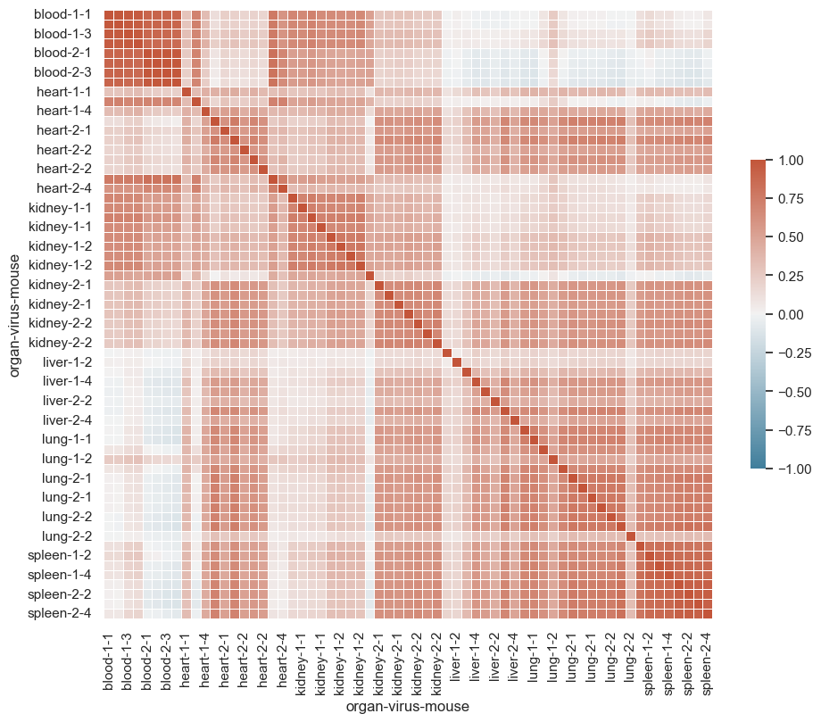

```python
# correlation map setting
sns.set_theme(style="white")
# Generate correlation data
corr = mouse_aa_sel_filtered_corr

# Generate a mask for the upper triangle
# mask = np.triu(np.ones_like(corr, dtype=bool))

# Set up the matplotlib figure
f, ax = plt.subplots(figsize=(11, 9))

# Generate a custom diverging colormap
cmap = sns.diverging_palette(230, 20, as_cmap=True)

# Draw the heatmap with the mask and correct aspect ratio
sns.heatmap(corr, cmap=cmap, vmax=1, vmin=-1, center=0,
            square=True, linewidths=.5, cbar_kws={"shrink": .5})
```

## Pearson within a tissue for all samples

```python
mouse_aa_sel_filtered_corr_cop = mouse_data_for_corr_plot.corr()
mouse_aa_sel_filtered_corr_cop = mouse_aa_sel_filtered_corr_cop.rename_axis(
    [None,None,None,None,None,None]).rename_axis( [None,None,None,None,None,None], axis=1)
```

```python
#rearrange the dataframe
mouse_corr_flatten_df = mouse_aa_sel_filtered_corr_cop.stack(list(range(0,6)))
mouse_corr_flatten_df
```

```
heart   1  1  1  mini    37  blood   1  1  1  qiagen  97     0.290127
                                        2  1  qiagen  98     0.285709
                                        3  1  qiagen  99     0.325723
                                        4  1  qiagen  100    0.339747
                                     2  1  1  qiagen  101    0.252041
                                                               ...
spleen  2  4  1  qiagen  8   spleen  1  4  1  qiagen  4      0.880598
                                     2  1  1  qiagen  5      0.924453
                                        2  1  qiagen  6      0.941712
                                        3  1  qiagen  7      0.926434
                                        4  1  qiagen  8      1.000000
Length: 3969, dtype: float64
```

```python
mouse_corr_flatten_df = mouse_corr_flatten_df.reset_index()[['level_0','level_6',0]]
mouse_corr_flatten_df
```

|  | level_0 | level_6 | 0 |
| --- | --- | --- | --- |
| 0 | heart | blood | 0.290127 |
| 1 | heart | blood | 0.285709 |
| 2 | heart | blood | 0.325723 |
| 3 | heart | blood | 0.339747 |
| 4 | heart | blood | 0.252041 |
| ... | ... | ... | ... |
| 3964 | spleen | spleen | 0.880598 |
| 3965 | spleen | spleen | 0.924453 |
| 3966 | spleen | spleen | 0.941712 |
| 3967 | spleen | spleen | 0.926434 |
| 3968 | spleen | spleen | 1.000000 |

3969 rows × 3 columns

```python
tissue_grabber = ['blood', 'heart', 'kidney', 'lung', 'liver','spleen']
```

```python
# rearrange the datafarme adn remove the duplicates
mouse_corr_intra_tissue =  pd.DataFrame()

for tissue in tissue_grabber:
    df = mouse_corr_flatten_df.query("level_0==@tissue").query("level_6==@tissue")
    mouse_corr_intra_tissue = pd.concat([mouse_corr_intra_tissue, df])

mouse_corr_intra_tissue.drop_duplicates(inplace=True)
mouse_corr_intra_tissue.head()
```

|  | level_0 | level_6 | 0 |
| --- | --- | --- | --- |
| 2457 | blood | blood | 1.000000 |
| 2458 | blood | blood | 0.978550 |
| 2459 | blood | blood | 0.962253 |
| 2460 | blood | blood | 0.953344 |
| 2461 | blood | blood | 0.890808 |

```python
# remove outliers
mouse_data = mouse_corr_intra_tissue[mouse_corr_intra_tissue[0]<1]
```

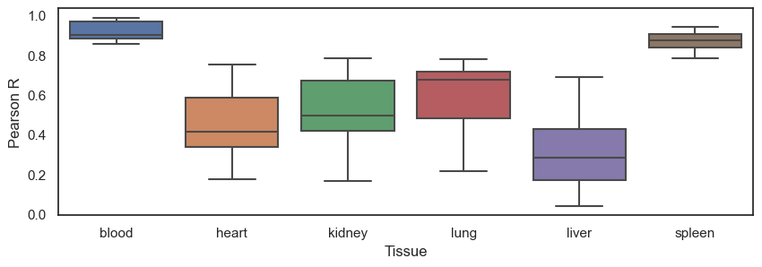

```python
# boxplot the pearson correlation data based on the organ type
fig,ax = plt.subplots(figsize=[10,3])
sns.boxplot(x='level_0', y=0, data=mouse_data)

ax.set_xlabel('Tissue')
ax.set_ylabel('Pearson R')
```

## Model Traning

```python
# https://scikit-learn.org/stable/modules/clustering.html
```

```python
# prepare the correlation data for PCA, drop all the NA, take log2 to all the values
mouse_dataset = mouse_data_for_corr_plot.T.groupby(level='organ').median().replace([np.inf,-np.inf,0],np.nan).apply(np.log2).T.dropna()
mouse_dataset
```

| abs_pos | aa | organ lib_type | blood | heart | kidney | liver | lung | spleen |
| --- | --- | --- | --- | --- | --- | --- | --- | --- |
| 1.0 | M | sub | -0.300561 | 0.016568 | -0.013215 | 0.039509 | 0.411641 | 0.056352 |
| 2.0 | R | sub | 0.547677 | -0.052163 | -0.022802 | -1.269652 | -0.452445 | 0.459704 |
| 2.5 | A | ins | 0.012121 | 0.276219 | 0.237355 | -0.002718 | 0.337235 | 0.283352 |
| 3.0 | - | del | -0.484042 | -0.613164 | -0.548516 | -0.872283 | -0.461372 | -0.287157 |
|  | A | sub | -0.059879 | 0.315028 | 0.387357 | -0.094653 | 0.721795 | 0.257355 |
| ... | ... | ... | ... | ... | ... | ... | ... | ... |
| 734.0 | T | sub | -0.134077 | 0.256891 | 0.129194 | 0.457033 | 0.524025 | 0.351354 |
|  | V | sub | 0.342437 | 0.199060 | 0.410636 | 0.361606 | 0.434635 | 0.568976 |
| 735.0 | I | sub | -0.452776 | 0.113757 | -0.083275 | 0.288884 | 0.332106 | -0.022203 |
|  | L | sub | -0.127183 | 0.134797 | 0.069456 | 0.483113 | 0.481966 | 0.317833 |
|  | V | sub | 0.046307 | 0.358950 | 0.273114 | 0.878949 | 0.626063 | 0.531547 |

6366 rows × 6 columns

```python
#combined the variants information to one column "loc"
mouse_dataset_filtered = mouse_dataset[mouse_dataset.apply(lambda x: abs(x)>1).any(axis=1)].reset_index()
mouse_dataset_filtered['loc'] = mouse_dataset_filtered['abs_pos'].astype(str) + mouse_dataset_filtered['aa']
mouse_dataset_filtered = mouse_dataset_filtered.drop(columns=['lib_type', 'abs_pos', 'aa'])
mouse_dataset_filtered
```

| organ | blood | heart | kidney | liver | lung | spleen | loc |
| --- | --- | --- | --- | --- | --- | --- | --- |
| 0 | 0.547677 | -0.052163 | -0.022802 | -1.269652 | -0.452445 | 0.459704 | 2.0R |
| 1 | 0.395270 | 0.819647 | 0.711656 | 0.395830 | 1.041985 | 0.687826 | 7.0F |
| 2 | -1.617234 | -1.398988 | -1.633125 | -8.150147 | -1.418705 | -1.207058 | 9.0D |
| 3 | 0.514174 | 0.488376 | 0.386753 | 1.319349 | 0.517831 | 0.902592 | 9.0E |
| 4 | 0.459520 | 0.231999 | 0.482842 | -2.281175 | 0.368368 | 0.703416 | 10.0K |
| ... | ... | ... | ... | ... | ... | ... | ... |
| 1847 | -1.036687 | 0.150341 | 0.322199 | -0.109423 | 0.287064 | 0.134370 | 724.0H |
| 1848 | -0.682494 | -0.097610 | 0.291682 | -1.043192 | -0.004082 | 0.366292 | 724.0W |
| 1849 | -1.877766 | -3.426688 | -2.466314 | -3.372452 | -1.874384 | -1.763342 | 725.5D |
| 1850 | -1.038680 | -0.688179 | -0.951636 | -0.598166 | -0.354725 | -0.646743 | 726.0V |
| 1851 | -0.251407 | -1.199514 | -0.965044 | -0.612063 | -0.952415 | -0.643804 | 734.0M |

1852 rows × 7 columns

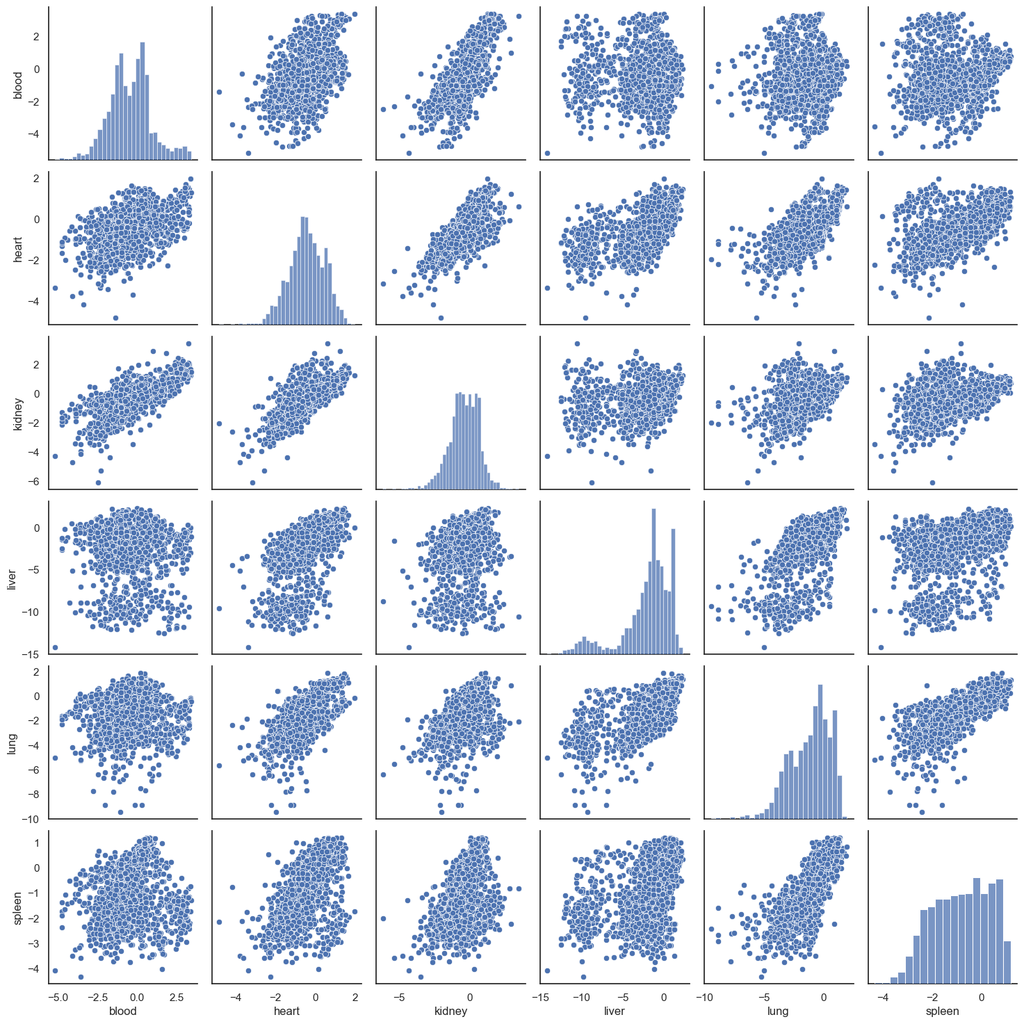

```python
#pairplot the prepaired dataframe
sns.pairplot(mouse_dataset_filtered)
```

```python
X = mouse_dataset_filtered
X
```

| organ | blood | heart | kidney | liver | lung | spleen | loc |
| --- | --- | --- | --- | --- | --- | --- | --- |
| 0 | 0.547677 | -0.052163 | -0.022802 | -1.269652 | -0.452445 | 0.459704 | 2.0R |
| 1 | 0.395270 | 0.819647 | 0.711656 | 0.395830 | 1.041985 | 0.687826 | 7.0F |
| 2 | -1.617234 | -1.398988 | -1.633125 | -8.150147 | -1.418705 | -1.207058 | 9.0D |
| 3 | 0.514174 | 0.488376 | 0.386753 | 1.319349 | 0.517831 | 0.902592 | 9.0E |
| 4 | 0.459520 | 0.231999 | 0.482842 | -2.281175 | 0.368368 | 0.703416 | 10.0K |
| ... | ... | ... | ... | ... | ... | ... | ... |
| 1847 | -1.036687 | 0.150341 | 0.322199 | -0.109423 | 0.287064 | 0.134370 | 724.0H |
| 1848 | -0.682494 | -0.097610 | 0.291682 | -1.043192 | -0.004082 | 0.366292 | 724.0W |
| 1849 | -1.877766 | -3.426688 | -2.466314 | -3.372452 | -1.874384 | -1.763342 | 725.5D |
| 1850 | -1.038680 | -0.688179 | -0.951636 | -0.598166 | -0.354725 | -0.646743 | 726.0V |
| 1851 | -0.251407 | -1.199514 | -0.965044 | -0.612063 | -0.952415 | -0.643804 | 734.0M |

1852 rows × 7 columns

## PCA for plotting

```python
# variant as label encoder
le = LabelEncoder()
X['loc'] = le.fit_transform(X['loc'])


# standardization
scaler = StandardScaler()
X = scaler.fit_transform(X)
X
```

```
array([[ 0.74021129,  0.44664892,  0.33912745, ...,  0.43817058,
         1.11387627, -1.43653573],
       [ 0.62818061,  1.42436535,  1.04461496, ...,  1.31025503,
         1.31116391,  1.6286596 ],
       [-0.85115601, -1.06378762, -1.20767671, ..., -0.12569639,
        -0.32759679,  1.70912566],
       ...,
       [-1.04266597, -3.33781153, -2.0080011 , ..., -0.3916107 ,
        -0.80869088,  1.66982828],
       [-0.42587628, -0.2666303 , -0.55306933, ...,  0.49519613,
         0.15698286,  1.67169958],
       [ 0.15282617, -0.84008203, -0.56594852, ...,  0.14640993,
         0.15952416,  1.67357089]])
```

```python
pca = PCA(n_components=7)
pca_data = pca.fit_transform(X)
```

```python
print(pca.explained_variance_ratio_)
```

```
[0.52501837 0.19929988 0.14224835 0.06531561 0.03285537 0.02129975
 0.01396267]
```

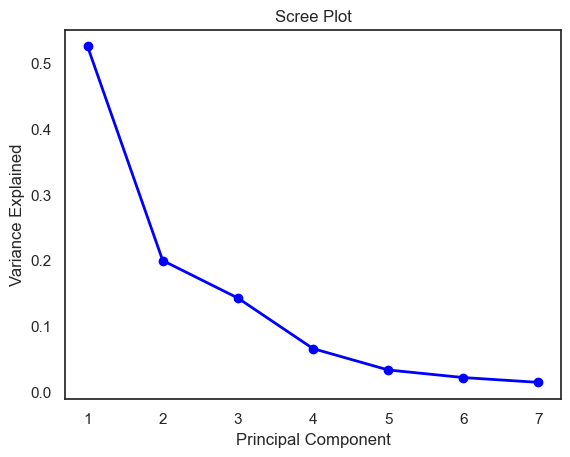

```python
# illustrate the informative principle components
PC_values = np.arange(pca.n_components_) + 1
plt.plot(PC_values, pca.explained_variance_ratio_, 'o-', linewidth=2, color='blue')
plt.title('Scree Plot')
plt.xlabel('Principal Component')
plt.ylabel('Variance Explained')
plt.show()
```

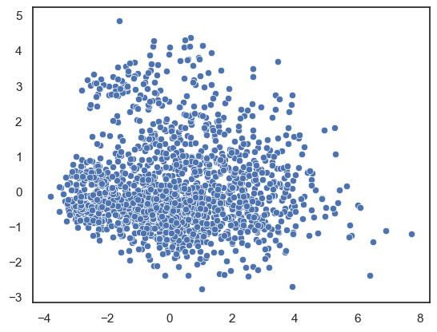

```python
sns.scatterplot(x=pca_data[:,0], y=pca_data[:,1])
```

## Calculate # of clusters

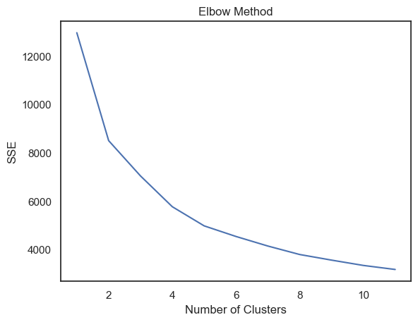

```python
# Determine the number of clusters based on elbow method
n=12
sse = []
for k in range(1, n, 1):
    kmeans = KMeans(n_clusters=k, max_iter=200).fit(X)
    sse.append(kmeans.inertia_)

plt.plot(range(1, n), sse)
plt.title("Elbow Method")
plt.xlabel("Number of Clusters")
plt.ylabel("SSE")
plt.show()
```

## K mean clustinng pipeline following PCA

```python
# source: https://realpython.com/k-means-clustering-python/
```

```python
preprocessor = Pipeline(
     [
         ("scaler", StandardScaler()),
         ("pca", PCA(n_components=2, random_state=0)),
     ]
 )
```

```python
clusterer = Pipeline(
    [
        (
            "kmeans",
            KMeans(
                n_clusters=6,
                init="k-means++",
                n_init=50,
                max_iter=500,
                random_state=0,
            ),
        )
    ]
 )
```

```python
pipe = Pipeline(
     [
         ("preprocessor", preprocessor),
         ("clusterer", clusterer)
     ]
 )
```

```python
pipe.fit(mouse_dataset_filtered)
```

```
Pipeline(steps=[('preprocessor',
                 Pipeline(steps=[('scaler', StandardScaler()),
                                 ('pca',
                                  PCA(n_components=2, random_state=0))])),
                ('clusterer',
                 Pipeline(steps=[('kmeans',
                                  KMeans(max_iter=500, n_clusters=6, n_init=50,
                                         random_state=0))]))])
```

```python
preprocessed_data = pipe["preprocessor"].transform(mouse_dataset_filtered)
preprocessed_data
```

```
array([[-1.45535491, -0.31324627],
       [-2.57457077,  0.52341905],
       [ 2.30030421,  0.24552043],
       ...,
       [ 3.54920074, -0.83922591],
       [ 0.17306814, -0.33704574],
       [ 0.45580696,  0.07875257]])
```

```python
predicted_labels = pipe["clusterer"]["kmeans"].labels_
```

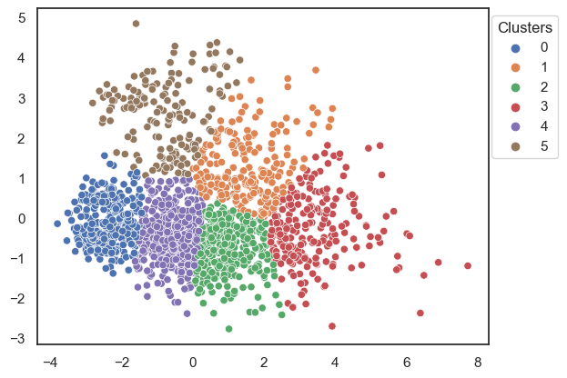

```python
p = sns.scatterplot(data = preprocessed_data, x=preprocessed_data[:,0], y=preprocessed_data[:,1], hue = predicted_labels, legend = "full", palette = "deep")
sns.move_legend(p, "upper right", bbox_to_anchor = (1.17, 1.), title = 'Clusters')
plt.show()
```

```python
mouse_dataset_filtered['label'] = predicted_labels
```

```python
mouse_dataset_filtered
```

| organ | blood | heart | kidney | liver | lung | spleen | loc | label |
| --- | --- | --- | --- | --- | --- | --- | --- | --- |
| 0 | 0.547677 | -0.052163 | -0.022802 | -1.269652 | -0.452445 | 0.459704 | 157 | 4 |
| 1 | 0.395270 | 0.819647 | 0.711656 | 0.395830 | 1.041985 | 0.687826 | 1795 | 0 |
| 2 | -1.617234 | -1.398988 | -1.633125 | -8.150147 | -1.418705 | -1.207058 | 1838 | 1 |
| 3 | 0.514174 | 0.488376 | 0.386753 | 1.319349 | 0.517831 | 0.902592 | 1839 | 0 |
| 4 | 0.459520 | 0.231999 | 0.482842 | -2.281175 | 0.368368 | 0.703416 | 0 | 0 |
| ... | ... | ... | ... | ... | ... | ... | ... | ... |
| 1847 | -1.036687 | 0.150341 | 0.322199 | -0.109423 | 0.287064 | 0.134370 | 1815 | 4 |
| 1848 | -0.682494 | -0.097610 | 0.291682 | -1.043192 | -0.004082 | 0.366292 | 1816 | 4 |
| 1849 | -1.877766 | -3.426688 | -2.466314 | -3.372452 | -1.874384 | -1.763342 | 1817 | 3 |
| 1850 | -1.038680 | -0.688179 | -0.951636 | -0.598166 | -0.354725 | -0.646743 | 1818 | 4 |
| 1851 | -0.251407 | -1.199514 | -0.965044 | -0.612063 | -0.952415 | -0.643804 | 1819 | 2 |

1852 rows × 8 columns

```python
organs = ['blood', 'heart', 'kidney', 'liver', 'lung', 'spleen']
```

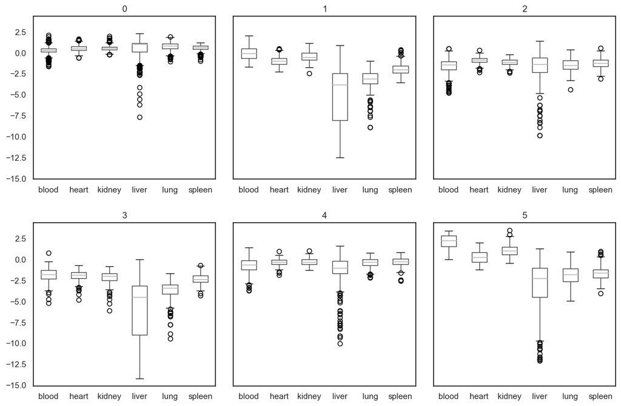

```python
# boxplot the organ distrution for each cluster
fig, axes = plt.subplots(2, 3, figsize=(12, 8), sharex=False, sharey=True)

mouse_dataset_filtered.groupby('label')[organs].boxplot(ax=axes, grid=False)
# plt.axhline(y=0.002, c="blue",linewidth=0.5,zorder=0)

fig.tight_layout(pad=2.0)
plt.show()
```

# Antibody experimental data analysis

```python
# create a antibody dataframe based on the experimental data
antibody_all = pd.read_csv("data/aav_antibody_all.csv.gz", index_col =list(range(0,11)))
```

```python
# make a copy of the dataframe
antibody_counts = antibody_all.copy()
antibody_counts
```

| abs_pos | tile_num | aa | is_wt_aa | is_wt_codon | wt_bc | lib_type | enzyme | codon | aa-codon | barcode | count | count.1 |
| --- | --- | --- | --- | --- | --- | --- | --- | --- | --- | --- | --- | --- |
| 1.0 | 0.0 | * | 0 | 0 | 0 | sub | bbsi | TAA | *-TAA | CACTGTCACACACTGACACT | 23.0 | 39.0 |
|  |  |  |  |  |  |  |  |  |  | CTGTGAGTGTGAGAGACACT | 31.0 | 42.0 |
|  |  |  |  |  |  |  |  | TAG | *-TAG | CTCTCACACAGTGAGTCTGA | 1.0 | 2.0 |
|  |  |  |  |  |  |  |  |  |  | CAGAGACAGAGTCTGTCACT | 10.0 | 8.0 |
|  |  |  |  |  |  |  |  | TGA | *-TGA | ACACTGTCTCTGTCAGACAG | 57.0 | 89.0 |
| ... | ... | ... | ... | ... | ... | ... | ... | ... | ... | ... | ... | ... |
| 735.5 | 18.0 | W | 0 | 0 | 0 | ins | bbsi | TGG | W-TGG | AGTCTGAGAGACTCTGACTG | 1.0 | 1.0 |
|  |  | Y | 0 | 0 | 0 | ins | bbsi | TAC | Y-TAC | GACTCTCACTCACACTGTGA | NaN | NaN |
|  |  |  |  |  |  |  |  |  |  | TGTCTCAGTCACACTGTGTG | 2.0 | 3.0 |
|  |  |  |  |  |  |  |  | TAT | Y-TAT | CACTGTGTGAGTCTGAGAGT | 11.0 | 2.0 |
|  |  |  |  |  |  |  |  |  |  | TGTCAGACACTCTGAGTGTC | 9.0 | 8.0 |

207168 rows × 2 columns

```python
#exam the dataframe for wildtype condon
antibody_counts.index.get_level_values(level=4).unique()
```

```
Index([0, 1], dtype='int64', name='is_wt_codon')
```

```python
#exam the dataframe for mutation type
antibody_counts.index.get_level_values(level=6).unique()
```

```
Index(['sub', 'del', 'ins'], dtype='object', name='lib_type')
```

```python
# count the wildtype row
total_wt_count = list(antibody_counts.index.get_level_values(level=4)).count(1)
total_wt_count
```

```
1118
```

```python
# count the mutant row
total_mut_count = list(antibody_counts.index.get_level_values(level=4)).count(0)
total_mut_count
```

```
206050
```

```python
# create an average count for each row
antibody_counts['avg'] = antibody_counts.apply(lambda x: np.mean([x['count'], x['count.1']]), axis=1)
```

```python
antibody_counts
```

| abs_pos | tile_num | aa | is_wt_aa | is_wt_codon | wt_bc | lib_type | enzyme | codon | aa-codon | barcode | count | count.1 | avg |
| --- | --- | --- | --- | --- | --- | --- | --- | --- | --- | --- | --- | --- | --- |
| 1.0 | 0.0 | * | 0 | 0 | 0 | sub | bbsi | TAA | *-TAA | CACTGTCACACACTGACACT | 23.0 | 39.0 | 31.0 |
|  |  |  |  |  |  |  |  |  |  | CTGTGAGTGTGAGAGACACT | 31.0 | 42.0 | 36.5 |
|  |  |  |  |  |  |  |  | TAG | *-TAG | CTCTCACACAGTGAGTCTGA | 1.0 | 2.0 | 1.5 |
|  |  |  |  |  |  |  |  |  |  | CAGAGACAGAGTCTGTCACT | 10.0 | 8.0 | 9.0 |
|  |  |  |  |  |  |  |  | TGA | *-TGA | ACACTGTCTCTGTCAGACAG | 57.0 | 89.0 | 73.0 |
| ... | ... | ... | ... | ... | ... | ... | ... | ... | ... | ... | ... | ... | ... |
| 735.5 | 18.0 | W | 0 | 0 | 0 | ins | bbsi | TGG | W-TGG | AGTCTGAGAGACTCTGACTG | 1.0 | 1.0 | 1.0 |
|  |  | Y | 0 | 0 | 0 | ins | bbsi | TAC | Y-TAC | GACTCTCACTCACACTGTGA | NaN | NaN | NaN |
|  |  |  |  |  |  |  |  |  |  | TGTCTCAGTCACACTGTGTG | 2.0 | 3.0 | 2.5 |
|  |  |  |  |  |  |  |  | TAT | Y-TAT | CACTGTGTGAGTCTGAGAGT | 11.0 | 2.0 | 6.5 |
|  |  |  |  |  |  |  |  |  |  | TGTCAGACACTCTGAGTGTC | 9.0 | 8.0 | 8.5 |

207168 rows × 3 columns

```python
# create an array for genomic position that bind to the A20 antibody
a20_postions_subs = np.array([261,262,263,264,384,385,708,717,258,253,254,658,659,660,548,556])
```

```python
# creat a subdataframe based on the genomic position of interest, only include the row that has subsititution, not stop codon, not wildtyp and drop NA
antibody_counts_a20 = antibody_counts.query("abs_pos in @a20_postions_subs").query("is_wt_aa==0").query("lib_type=='sub'").query("aa!='*'")[['avg']].dropna()
antibody_counts_a20
```

| abs_pos | tile_num | aa | is_wt_aa | is_wt_codon | wt_bc | lib_type | enzyme | codon | aa-codon | barcode | avg |
| --- | --- | --- | --- | --- | --- | --- | --- | --- | --- | --- | --- |
| 253.0 | 6.0 | C | 0 | 0 | 0 | sub | bbsi | TGC | C-TGC | CTCTGTCAGTCAGTGTGTCA | 5.5 |
|  |  | D | 0 | 0 | 0 | sub | bbsi | GAC | D-GAC | ACAGTGACTCACTCTCTCTC | 253.0 |
|  |  |  |  |  |  |  |  |  |  | GTCAGTCACACTCACACACT | 20.0 |
|  |  |  |  |  |  |  |  | GAT | D-GAT | ACACTCACTCTGACTGACAG | 219.0 |
|  |  |  |  |  |  |  |  |  |  | TGTCACTCTCTCAGTCAGTG | 191.0 |
| ... | ... | ... | ... | ... | ... | ... | ... | ... | ... | ... | ... |
| 717.0 | 18.0 | W | 0 | 0 | 0 | sub | bbsi | TGG | W-TGG | AGTGAGTGACTGTGTGAGTC | 15.5 |
|  |  | Y | 0 | 0 | 0 | sub | bbsi | TAC | Y-TAC | GACACAGTCTGAGACTCACT | 2494.0 |
|  |  |  |  |  |  |  |  |  |  | CAGAGTGTGACACAGAGTGA | 21.0 |
|  |  |  |  |  |  |  |  | TAT | Y-TAT | CTCAGACTGTCTCAGTGTGA | 28.0 |
|  |  |  |  |  |  |  |  |  |  | ACACACAGTCTGTCTGTCTG | 1173.5 |

1466 rows × 1 columns

```python
# take the average of count for mutant
mut_avg_count = antibody_counts_a20['avg'].mean()
mut_avg_count
```

```
810.4945429740791
```

```python
# take the average of count for wildtype
wt_avg_count = antibody_counts.query("abs_pos in @a20_postions_subs").query("is_wt_aa==1")['avg'].mean()
wt_avg_count
```

```
64.9
```

```python
avg_count_plot = pd.DataFrame(data=[mut_avg_count, wt_avg_count], columns=['avg count'], index=['mutant', 'wild type'])
avg_count_plot
```

|  | avg count |
| --- | --- |
| mutant | 810.494543 |
| wild type | 64.900000 |

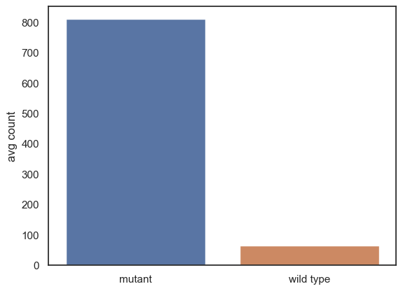

```python
# plot the data to compare wildtype count and mutant count based on the A20 antibody binding postion.
sns.barplot(data=avg_count_plot, x=avg_count_plot.index, y="avg count")
```

## Heatmap of count for positions known to interact with a20 antibody

```python
antibody_counts_a20
```

| abs_pos | tile_num | aa | is_wt_aa | is_wt_codon | wt_bc | lib_type | enzyme | codon | aa-codon | barcode | avg |
| --- | --- | --- | --- | --- | --- | --- | --- | --- | --- | --- | --- |
| 253.0 | 6.0 | C | 0 | 0 | 0 | sub | bbsi | TGC | C-TGC | CTCTGTCAGTCAGTGTGTCA | 5.5 |
|  |  | D | 0 | 0 | 0 | sub | bbsi | GAC | D-GAC | ACAGTGACTCACTCTCTCTC | 253.0 |
|  |  |  |  |  |  |  |  |  |  | GTCAGTCACACTCACACACT | 20.0 |
|  |  |  |  |  |  |  |  | GAT | D-GAT | ACACTCACTCTGACTGACAG | 219.0 |
|  |  |  |  |  |  |  |  |  |  | TGTCACTCTCTCAGTCAGTG | 191.0 |
| ... | ... | ... | ... | ... | ... | ... | ... | ... | ... | ... | ... |
| 717.0 | 18.0 | W | 0 | 0 | 0 | sub | bbsi | TGG | W-TGG | AGTGAGTGACTGTGTGAGTC | 15.5 |
|  |  | Y | 0 | 0 | 0 | sub | bbsi | TAC | Y-TAC | GACACAGTCTGAGACTCACT | 2494.0 |
|  |  |  |  |  |  |  |  |  |  | CAGAGTGTGACACAGAGTGA | 21.0 |
|  |  |  |  |  |  |  |  | TAT | Y-TAT | CTCAGACTGTCTCAGTGTGA | 28.0 |
|  |  |  |  |  |  |  |  |  |  | ACACACAGTCTGTCTGTCTG | 1173.5 |

1466 rows × 1 columns

```python
antibody_counts_a20_heatmap = antibody_counts_a20.groupby(['abs_pos', 'aa'])['avg'].mean().unstack(0)
antibody_counts_a20_heatmap = np.log(antibody_counts_a20_heatmap)
antibody_counts_a20_heatmap.columns = antibody_counts_a20_heatmap.columns.astype('int')
```

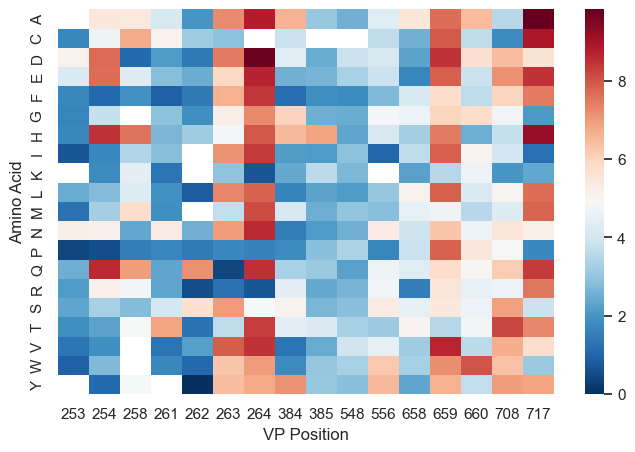

```python
# plot the heatmap of the counts based on each aminoacid change at each genomic position.
fig,ax =plt.subplots(figsize=[8, 5])
sns.heatmap(antibody_counts_a20_heatmap, cmap='RdBu_r', ax=ax, yticklabels=True)
ax.set_ylabel("Amino Acid")
ax.set_xlabel("VP Position")
```